# Brandi Pessman - Data Science Portfolio

2025-04-15

Lincoln, Nebraska, USA | bjpessman@gmail.com | [GitHub](https://github.com/brandipessman) | [LinkedIn](https://www.linkedin.com/in/brandipessman/)

# About Me

I have a passion for patterns - whether crocheting, sewing, observing spider webs, or coding. I have been uncovering patterns in complex datasets to tell stories that inform and innovate for the past six years. I am a data scientist with a Ph.D. from the University of Nebraska-Lincoln. My expertise lies in statistics, predictive modeling, pipeline production, data analytics, visualizations, wrangling, and geospatial analysis using languages/tools like R, Python, SQL, Unix, Git, high-throughput computing, and QGIS.

I excel at designing scalable workflows and statistical models that transform raw data into resolutions that drive decision-making and innovation. By applying advanced analytical techniques to biological systems, I have developed a deep understanding of complex, dynamic data - skills that translate to solving real-world challenges in industry.

*Below are selected snippets of projects demonstrating my relevant experiences. The code behind the graphics and tables can be expanded throughout to showcase my skills in data wrangling, statistical analysis, and visualization using Python, R, or SQL languages.*

# Featured Projects

## Modeling Computer-Trained Poses [Python]

**ONGOING**

[figure not shown]

- **Tech Stack**: Python, Unix, DeepLabCut, OSPool, HTCondor, High-Throughput Computing
- **Motivation**: Quantify leg movements during mating displays across 22 species of wolf spiders (~1000 videos) to test if the complexity of visual displays are predictable across species.
- **Impact**: Applied machine learning and high-throughput computing to automate behavioral analysis, reducing manual video annotation time and enhancing the study of motion patterns in biomechanics.

– Built and implemented a container for DeepLabCut, a deep-learning pose estimation software, to use on the remote servers of the Open Science Pool (OSPool).

– Utilized machine learning to train the computer to learn key point positions on spider legs during mating displays.

– Designed an efficient workflow on the remote server to train the model, evaluate the network, and run inference on 1000 videos.

– Collaborated with a brilliant research team who recorded the videos, extracted and labeled frames, and are working to group species with similar visual displays.

### Remote Computer Scripts

– Wrote scripts that communicate with each other on the remote server to run a defined job - in this case, to use a trained model to estimate poses frame-by-frame.

#### Python Script

This script sets the directory of the selected videos and runs functions in the DeepLabCut container that runs inference from the trained model on all videos in the specified path.

```bash
import deeplabcut
import os
import sys

video = sys.argv[1]
config = "path"

current_directory = os.getcwd()
config_path = os.path.join(current_directory, config, 'config.yaml')
video_path = os.path.join(current_directory, video)
dest_path = os.path.join(current_directory, config, 'results')

deeplabcut.analyze_videos(config_path, [video_path], save_as_csv=True,
                          destfolder=dest_path)
deeplabcut.filterpredictions(config_path, [video_path], destfolder=dest_path)
```

#### Shell Script

This scipt runs some necessary commands to ensure the DeepLabCut container is communicating with all necessary directories. It implements safeguards to ensure videos are properly formatted before running the Python script and tarring the results for output.

```bash
video=$1

mkdir -p /tmp/pretrained
ls /usr/local/lib
cp /usr/local/lib/python3.10/dist-packages/deeplabcut/pose_estimation_tensorflow/models/
    pretrained.ORIG/*.yaml /tmp/pretrained
cp /usr/local/lib/python3.10/dist-packages/deeplabcut/pose_estimation_tensorflow/models/
    pretrained.ORIG/*.py /tmp/pretrained

tar -xzf tar3_evaluated.tar.gz -C /srv
mkdir /srv/path/results

if [[ "$video" == *.MP4 ]]; then
    python3.10 deeplabcut_analysis.py $video

else
    echo "Unsupported video format: $video. Please use .MP4."
    exit 1
fi

tar -czf results_${video}.tar.gz path/
```

#### Submission File

This script is necessary for the HTConder system to distribute jobs to the pool of servers. It defines the input/output files, container location, computer requirements, and queue statement to parallel-process videos.

```bash
video = $Fnx(videopath)
executable = deeplabcut_analysis.sh
arguments = $(video)

transfer_input_files = tar3_evaluated.tar.gz, deeplabcut_analysis.py, osdf://$(videopath)
transfer_output_remaps = "results_$(video).tar.gz = results/results_$(video).tar.gz"

universe = container
container_image = osdf:///path/DeepLabCut.sif

output = output/output_$(video).out
error = error/error_$(video).err
log = log/log_$(video).log

gpus_minimum_capability = 8.0
request_gpus = 1
request_cpus = 2
request_memory = 40GB
request_disk = 25GB

requirements = regexp("GP-ARGO", GLIDEIN_ResourceName) != True &&
                     (GLIDEIN_ResourceName =!= MY.GLIDEIN_ResourceName0) &&
                     (GLIDEIN_ResourceName =!= MY.GLIDEIN_ResourceName1) &&
                     (GLIDEIN_ResourceName =!= MY.GLIDEIN_ResourceName2)

queue videopath matching path/*.MP4
```

### Visualizing Leg Movement

– Processed the resulting CSV file to graph the y-coordinates of different body parts of the spider across video frames to predict leg movements.

The spinnerets act as a baseline because the line should be horizontally flat if the spider is not moving. The left leg was raised where the pink/purple lines rise and likewise for the right leg with the orange/green lines. Further analysis can categorize patterns of rising/lowering legs and cluster by species.

[figure not shown]

```python
import pandas as pd
from pathlib import Path
import numpy as np
import os
import matplotlib.pyplot as plt

Dataframe = pd.read_csv(os.path.join('sg138-19_C0038_filtered.csv'))

df_melted_y = Dataframe.melt(id_vars=['coords'],
                    value_vars=[col for col in Dataframe.columns if col.endswith('.y')],
                    var_name='bodypart',
                    value_name='y')

df_melted_lh = Dataframe.melt(id_vars=['coords'],
                    value_vars=[col for col in Dataframe.columns if col.endswith('.lh')],
                    var_name='bodypart',
                    value_name='lh')
df_melted_lh = df_melted_lh[df_melted_lh['lh'] > 0.5]

merged_df = pd.merge(df_melted_y, df_melted_lh, on=['coords'], how='left')
merged_df = merged_df.dropna()
merged_df = merged_df[merged_df['bodypart_x'].isin(['TR1.y', 'MR1.y', 'TL1.y',
                                                    'ML1.y', 'S.y'])]

plt.figure(figsize=(10, 6))

unique_bodyparts = merged_df['bodypart_x'].unique()
plt.rcParams.update({'font.size': 16})

colors = plt.cm.Dark2(range(len(unique_bodyparts)))

for i, bodypart in enumerate(unique_bodyparts):
    bodypart_data = merged_df[merged_df['bodypart_x'] == bodypart]

    plt.plot(bodypart_data['coords'], bodypart_data['y'], label=bodypart, color=colors[i])

plt.xlabel('Frame')
plt.ylabel('Y Coordinate')

handles, labels = plt.gca().get_legend_handles_labels()
new_labels = ['Tarsus R', 'Metatarsus R', 'Tarsus L', 'Metatarsus L', 'Spinnerets']
plt.legend(handles, new_labels, loc="lower right")

plt.xlim(5000, 8000)
plt.ylim(400, 900)

plt.show()
```

## Querying Sci-Comm Training Surveys [SQL, R]

**ONGOING**

- **Tech Stack**: SQL (PostgreSQL), R
- **Motivation**: Created a relational database in PostgreSQL for survey data completed by participants in science communication training workshops to assess outcomes.
- **Impact**: Wrote SQL queries to analyze outcomes of science communication training workshops led through collaboration with my principal investigator to understand the impact of such training on participants perspectives on science communication.

– Created a relational database of surveys completed by participants of a science communication training workshop called Nebraska Science Ambassadors:

[Bold indicates **primary key**; Italics indicates *foreign key*.]

**module1, module2, module3, module4, pretest, postest**: surveys completed before the training (pretest) after each module in the workshop series (module*) and after the workshop series (postest)

[**entry**, *recipient_id*, recorded_date, duration_s, progress, module, *question_id*, answer]

**partcipants**: participant information

[**recipient_id**, recipient_name, iteration]

**questions**: questions used in the surveys

[**question_id**, answer_type, definition1, definition2, definition3, definition4, definition5, definition6, definition7, definition8, question_type, question]

– Queried survey data using SQL in PostgreSQL to run analyses in R to assess participant outcomes from science communication training.

### Participation in Modules

*Three cohorts of participants completed the training (Spring 2022, Fall 2022, Spring 2023), each with four modules of information. In the post-training survey, participants selected which of the four modules they completed. This query grabs the responses and counts the number of modules that each participant said they attended.*

```sql
SELECT posttest.recipient_id, iteration, COUNT(answer) AS answer_count
FROM training.posttest
JOIN training.participants
ON posttest.recipient_id = participants.recipient_id
JOIN training.questions
ON posttest.question_id = questions.question_id
WHERE posttest.question_id LIKE 'participation%'
AND posttest.question_id NOT LIKE 'participation5'
GROUP BY posttest.recipient_id, iteration
ORDER BY posttest.recipient_id;
```

Only showing the first 5 rows.

| recipient_id | iteration | answer_count |
| --- | --- | --- |
| 1 | Spring 2022 | 3 |
| 2 | Spring 2023 | 3 |
| 4 | Spring 2023 | 3 |
| 5 | Spring 2022 | 4 |
| 6 | Spring 2023 | 3 |

*I can then graph the percentage and number of participants from each cohort that completed all (4) or some of the training modules.*

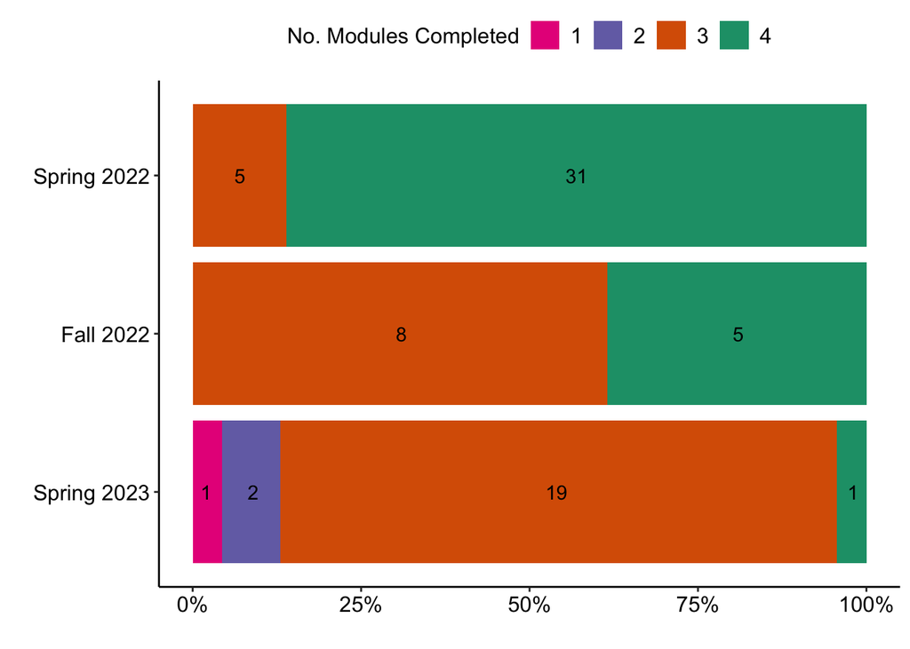

```r
iteration_count <- participation_counts_modules %>%
  group_by(iteration, answer_count) %>%
  count() %>%
  filter(iteration != "All") %>%
  mutate(answer_count = factor(answer_count),
         answer_count = fct_relevel(answer_count, "4", "3", "2", "1"),
         iteration = factor(iteration),
         iteration = fct_relevel(iteration,
                                 "Spring 2023", "Fall 2022", "Spring 2022"))
iteration_count$position <- c(0.31, 0.81, 0.07, 0.57, 0.02, 0.09, 0.54, 0.98)

four_colors = c("#1b9e77", "#d95f02", "#7570b3", "#e7298a")

iteration_count %>%
  ggplot() +
    geom_bar(aes(x = n, y = iteration, fill = answer_count),
             position = "fill", stat = "identity") +
    geom_text(aes(x = position, y = iteration, label = n)) +
    scale_x_continuous(labels = scales::percent) +
    scale_fill_manual("No. Modules Completed",
                 values = four_colors) +
    xlab("") +
    ylab("") +
    theme_classic() +
    theme(legend.position = "top",
        axis.text = element_text(size = 12, color = "black"),
        legend.text = element_text(size = 12, color = "black"),
        legend.title = element_text(size = 12, color = "black")) +
    guides(fill = guide_legend(reverse=TRUE))
```

**As time went on, cohorts were finishing fewer of the four modules.**

### Outcomes of Training

#### Module Efficacy

*I queried the responses to the surveys following module 1. I repeated this query for each of the four modules.*

```sql
SELECT iteration, module, module1.question_id, definition_1, definition_2,
  definition_3, definition_4, definition_5, question, answer,
  COUNT(module1.recipient_id) AS response
FROM training.module1
JOIN training.participants
ON module1.recipient_id = participants.recipient_id
JOIN training.questions
ON module1.question_id = questions.question_id
GROUP BY iteration, module, module1.question_id, definition_1, definition_2,
  definition_3, definition_4, definition_5, question, answer
ORDER BY iteration, question_id, answer;
```

Only showing the first 3 rows.

| iteration | module | question_id | definition_1 | definition_2 | definition_3 | definition_4 | definition_5 | question | answer | response |
| --- | --- | --- | --- | --- | --- | --- | --- | --- | --- | --- |
| All | 1 | eval1_1 | Strongly disagree | Somewhat disagree | Neither agree nor disagree | Somewhat agree | Strongly agree | I am able to define ‘science communication’. | 4 | 1 |
| All | 1 | eval1_1 | Strongly disagree | Somewhat disagree | Neither agree nor disagree | Somewhat agree | Strongly agree | I am able to define ‘science communication’. | 5 | 2 |
| All | 1 | eval1_2 | Strongly disagree | Somewhat disagree | Neither agree nor disagree | Somewhat agree | Strongly agree | I am able to identify some of the challenges of communicating about science. | 5 | 3 |

*I used R code to count the number of participants that selected each unique response which ranged from “Strongly disagree” (1) to “Strongly agree” (5). Then, I graphed the percentage of participants selecting each response for each question. I indicated the number of participants at the end of each bar.*

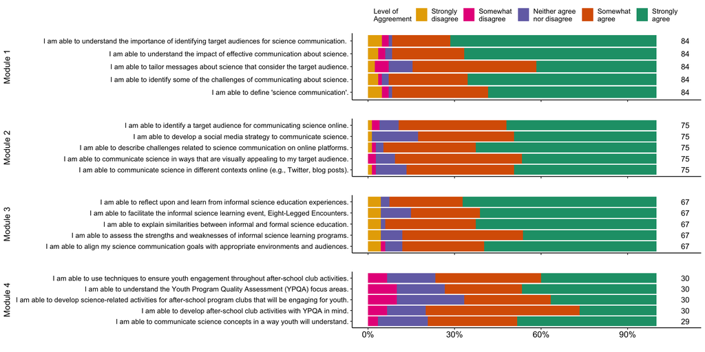

```r
five_colors = c("#1b9e77", "#d95f02", "#7570b3", "#e7298a", "#e6ab02")

module1_training <- module1_training %>%
  filter(answer != "NULL",
         iteration != "All") %>%
  mutate(answer = ifelse(answer == 1, "Strongly \ndisagree",
                  ifelse(answer == 2, "Somewhat \ndisagree",
                  ifelse(answer == 3, "Neither agree \nnor disagree",
                  ifelse(answer == 4, "Somewhat \nagree",
                  ifelse(answer == 5, "Strongly \nagree", "NA"))))),
         answer = fct_relevel(answer, "Strongly \nagree", "Somewhat \nagree",
                              "Neither agree \nnor disagree", "Somewhat \ndisagree",
                              "Strongly \ndisagree"),
         iteration, fct_relevel(iteration, "Spring 2023", "Fall 2022", "Spring 2022")) %>%
  dplyr::select(iteration, question_id, question, answer, response) %>%
  group_by(question_id, question, answer) %>%
  summarize(response = sum(response))

sum_module1 <- module1_training %>%
  group_by(question) %>%
  summarize(total = sum(response)) %>%
  mutate(y = 1.1)

module1_graph <- ggplot() +
    geom_bar(aes(x = response, y = question, fill = answer),
             position = "fill", stat = "identity", data = module1_training) +
    geom_text(aes(x = y, y = question, label = total), data = sum_module1) +
    scale_x_continuous(labels = scales::percent) +
    scale_fill_manual("Level of \nAggreement",
                 values = five_colors) +
    xlab("") +
    ylab("Module 1") +
    theme_classic() +
    theme(legend.position = "top",
        axis.text.x = element_blank(),
        axis.title.y = element_text(size = 12, color = "black"),
        axis.text.y = element_text(size = 10, color = "black"),
        legend.text = element_text(size = 10, color = "black"),
        legend.title = element_text(size = 10, color = "black")) +
    guides(fill = guide_legend(reverse=TRUE))

# Module 2
module2_training <- module2_training %>%
  filter(answer != "NULL",
         iteration != "All") %>%
  mutate(answer = ifelse(answer == 1, "Strongly \ndisagree",
                  ifelse(answer == 2, "Somewhat \ndisagree",
                  ifelse(answer == 3, "Neither agree \nnor disagree",
                  ifelse(answer == 4, "Somewhat \nagree",
                  ifelse(answer == 5, "Strongly \nagree", "NA"))))),
         answer = fct_relevel(answer, "Strongly \nagree", "Somewhat \nagree",
                              "Neither agree \nnor disagree", "Somewhat \ndisagree",
                              "Strongly \ndisagree"),
         iteration, fct_relevel(iteration, "Spring 2023", "Fall 2022", "Spring 2022")) %>%
  dplyr::select(iteration, question_id, question, answer, response) %>%
  group_by(question_id, question, answer) %>%
  summarize(response = sum(response))

sum_module2 <- module2_training %>%
  group_by(question) %>%
  summarize(total = sum(response)) %>%
  mutate(y = 1.1)

module2_graph <- ggplot() +
    geom_bar(aes(x = response, y = question, fill = answer),
             position = "fill", stat = "identity", data = module2_training) +
    geom_text(aes(x = y, y = question, label = total), data = sum_module2) +
    scale_x_continuous(labels = scales::percent) +
    scale_fill_manual("Level of Aggreement",
                 values = five_colors) +
    xlab("") +
    ylab("Module 2") +
    theme_classic() +
    theme(legend.position = "none",
          axis.text.x = element_blank(),
          axis.title.y = element_text(size = 12, color = "black"),
          axis.text.y = element_text(size = 10, color = "black"),
          legend.text = element_text(size = 10, color = "black"),
          legend.title = element_text(size = 10, color = "black"))

# Module 3
module3_training <- module3_training %>%
  filter(answer != "NULL",
         iteration != "All") %>%
  mutate(answer = ifelse(answer == 1, "Strongly \ndisagree",
                  ifelse(answer == 2, "Somewhat \ndisagree",
                  ifelse(answer == 3, "Neither agree \nnor disagree",
                  ifelse(answer == 4, "Somewhat \nagree",
                  ifelse(answer == 5, "Strongly \nagree", "NA"))))),
         answer = fct_relevel(answer, "Strongly \nagree", "Somewhat \nagree",
                              "Neither agree \nnor disagree", "Somewhat \ndisagree",
                              "Strongly \ndisagree"),
         iteration, fct_relevel(iteration, "Spring 2023", "Fall 2022", "Spring 2022")) %>%
  dplyr::select(iteration, question_id, question, answer, response) %>%
  group_by(question_id, question, answer) %>%
  summarize(response = sum(response))

sum_module3 <- module3_training %>%
  group_by(question) %>%
  summarize(total = sum(response)) %>%
  mutate(y = 1.1)

module3_graph <- ggplot() +
    geom_bar(aes(x = response, y = question, fill = answer),
             position = "fill", stat = "identity", data = module3_training) +
    geom_text(aes(x = y, y = question, label = total), data = sum_module3) +
    scale_x_continuous(labels = scales::percent) +
    scale_fill_manual("Level of Aggreement",
                 values = five_colors) +
    xlab("") +
    ylab("Module 3") +
    theme_classic() +
    theme(legend.position = "none",
          axis.text.x = element_blank(),
          axis.title.y = element_text(size = 12, color = "black"),
          axis.text.y = element_text(size = 10, color = "black"),
          legend.text = element_text(size = 10, color = "black"),
          legend.title = element_text(size = 10, color = "black"))

# Module 4
module4_training <- module4_training %>%
  filter(answer != "NULL",
         iteration != "All") %>%
  mutate(answer = ifelse(answer == 1, "Strongly \ndisagree",
                  ifelse(answer == 2, "Somewhat \ndisagree",
                  ifelse(answer == 3, "Neither agree \nnor disagree",
                  ifelse(answer == 4, "Somewhat \nagree",
                  ifelse(answer == 5, "Strongly \nagree", "NA"))))),
         answer = fct_relevel(answer, "Strongly \nagree", "Somewhat \nagree",
                              "Neither agree \nnor disagree", "Somewhat \ndisagree",
                              "Strongly \ndisagree"),
         iteration, fct_relevel(iteration, "Spring 2023", "Fall 2022", "Spring 2022")) %>%
  dplyr::select(iteration, question_id, question, answer, response) %>%
  group_by(question_id, question, answer) %>%
  summarize(response = sum(response))

sum_module4 <- module4_training %>%
  group_by(question) %>%
  summarize(total = sum(response)) %>%
  mutate(y = 1.1)

module4_graph <- ggplot() +
    geom_bar(aes(x = response, y = question, fill = answer),
             position = "fill", stat = "identity", data = module4_training) +
    geom_text(aes(x = y, y = question, label = total), data = sum_module4) +
    scale_x_continuous(labels = scales::percent) +
    scale_fill_manual("Level of Aggreement",
                 values = five_colors) +
    xlab("") +
    ylab("Module 4") +
    theme_classic() +
    theme(legend.position = "none",
          axis.text.x = element_text(size = 12, color = "black"),
          axis.text.y = element_text(size = 10, color = "black"),
          axis.title.y = element_text(size = 12, color = "black"),
          legend.text = element_text(size = 10, color = "black"),
          legend.title = element_text(size = 10, color = "black"))

plot_grid(module1_graph, module2_graph, module3_graph, module4_graph, ncol=1,
          align="v", rel_heights = c(1.5, 1, 1, 1.1))
```

#### Impact on Sci-Comm Attitudes

*I queried the responses of each participant that completed pre- and post-training surveys.*

```sql
select pretest.recipient_id, iteration, pretest.question_id, question, answer_type,
  definition_1, definition_2, definition_3, definition_4, definition_5,
  pretest.answer as pre_answer, posttest.answer as post_answer
FROM training.pretest
JOIN training.posttest
ON pretest.recipient_id = posttest.recipient_id
  AND pretest.question_id = posttest.question_id
JOIN training.questions
ON pretest.question_id = questions.question_id
JOIN training.participants
ON pretest.recipient_id = participants.recipient_id
WHERE pretest.answer IS NOT NULL AND posttest.answer IS NOT NULL
AND pretest.question_id NOT LIKE 'prepost3_%'
ORDER BY question_id;
```

Only showing the first 3 rows.

| recipient_id | iteration | question_id | question | answer_type | definition_1 | definition_2 | definition_3 | definition_4 | definition_5 | pre_answer | post_answer |
| --- | --- | --- | --- | --- | --- | --- | --- | --- | --- | --- | --- |
| 1 | Spring 2022 | prepost7_1 | Engaging in science communication improves my self worth. | Level of Agreement | Strongly disagree | Somewhat disagree | Neither agree nor disagree | Somewhat agree | Strongly agree | 4 | 5 |
| 1 | Spring 2022 | prepost7_2 | Successfully communicating my research to the public makes me feel good about myself. | Level of Agreement | Strongly disagree | Somewhat disagree | Neither agree nor disagree | Somewhat agree | Strongly agree | 5 | 5 |
| 1 | Spring 2022 | prepost7_3 | I believe engaging in science communication is necessary for me to feel successful. | Level of Agreement | Strongly disagree | Somewhat disagree | Neither agree nor disagree | Somewhat agree | Strongly agree | 4 | 4 |

*I used a paired t-test to test whether responses to each shared question differed between pre- and post-training surveys. To graph the questions that showed a significant shift, I subtracted each pre-training response from the post-training response.*

Asterisks indicate significance level of the departure from 0 (no change) ‘before / after’ Bonferroni p-value correction (*** P < 0.001, ** P < 0.01, * P < 0.05, . P < 0.1, NS P > 0.1).

The number to the right indicates the average answer value from the post-training survey (range 1-5).

```r
pre_post_10 <- pre_post %>%
  filter(question_id == "prepost10")
t.test(x = pre_post_10$pre_answer, y = pre_post_10$post_answer, paired = TRUE)$p.value
```

```
## [1] 1.2613e-08
```

```r
p.adjust(t.test(x = pre_post_10$pre_answer, y = pre_post_10$post_answer, paired = TRUE)$p.value,
         method = "bonferroni", n = 6)
```

```
## [1] 7.567801e-08
```

```r
pre_post_10_selected <- pre_post_10 %>%
  mutate(change = post_answer - pre_answer) %>%
  group_by(question_id, question) %>%
  summarize(mean_change = mean(change),
            se_change = plotrix::std.error(change)) %>%
  mutate(y = 1.2,
         y2 = 1,
         post_mean = round(mean(pre_post_10$post_answer), 2),
         stats = "*** / ***",
         question = "How good are you at science communication?") %>%
  ggplot() +
    geom_point(aes(x = mean_change, y = question), color = "#7570b3") +
    geom_errorbar(aes(xmax = mean_change + 1.96 * se_change, xmin = mean_change - 1.96 * se_change,
                      y = question), width = 0.25, color = "#7570b3") +
    geom_vline(xintercept = 0, linetype = "dashed", color = "#7570b3") +
    geom_text(aes(x = y2, y = question, label = stats), size = 4, color = "#7570b3") +
    geom_text(aes(x = y, y = question, label = post_mean), size = 4, color = "#7570b3") +
    scale_x_continuous(limits = c(-0.7, 1.3), breaks = c(seq(-0.5, 1, 0.5))) +
    ylab("") +
    xlab("Change toward 'not at all good' ------------------ Change toward 'very good'") +
    theme_classic() +
    theme(legend.position = "none",
          axis.text.y = element_text(size = 10, color = "black"),
          axis.text.x = element_text(size = 10, color = "black"),
          axis.title.x = element_text(size = 10, color = "black"))

pre_post_11 <- pre_post %>%
  filter(question_id == "prepost11")
t.test(x = pre_post_11$pre_answer, y = pre_post_11$post_answer, paired = TRUE)$p.value
```

```
## [1] 1.631999e-09
```

```r
p.adjust(t.test(x = pre_post_11$pre_answer, y = pre_post_11$post_answer, paired = TRUE)$p.value,
         method = "bonferroni", n = 6)
```

```
## [1] 9.791995e-09
```

```r
pre_post_11_selected <- pre_post_11 %>%
  mutate(change = post_answer - pre_answer) %>%
  group_by(question_id, question) %>%
  summarize(mean_change = mean(change),
            se_change = plotrix::std.error(change)) %>%
  mutate(y = 1.2,
         y2 = 1,
         post_mean = round(mean(pre_post_11$post_answer), 2),
         stats = "*** / ***",
         question = "How well does the public understand your \nscience when you communicate it to them?") %>%
  ggplot() +
    geom_point(aes(x = mean_change, y = question), color = "#7570b3") +
    geom_errorbar(aes(xmax = mean_change + 1.96 * se_change, xmin = mean_change - 1.96 * se_change,
                      y = question), width = 0.25, color = "#7570b3") +
    geom_vline(xintercept = 0, linetype = "dashed", color = "#7570b3") +
    geom_text(aes(x = y2, y = question, label = stats), size = 4, color = "#7570b3") +
    geom_text(aes(x = y, y = question, label = post_mean), size = 4, color = "#7570b3") +
    scale_x_continuous(limits = c(-0.7, 1.3), breaks = c(seq(-0.5, 1, 0.5))) +
    ylab("") +
    xlab("Change toward less understanding --- Change toward more understanding") +
    theme_classic() +
    theme(legend.position = "none",
          axis.text.y = element_text(size = 10, color = "black"),
          axis.text.x = element_text(size = 10, color = "black"),
          axis.title.x = element_text(size = 10, color = "black"))

pre_post_12 <- pre_post %>%
  filter(question_id == "prepost12")
t.test(x = pre_post_12$pre_answer, y = pre_post_12$post_answer, paired = TRUE)$p.value
```

```
## [1] 0.03296817
```

```r
p.adjust(t.test(x = pre_post_12$pre_answer, y = pre_post_12$post_answer, paired = TRUE)$p.value,
         method = "bonferroni", n = 6)
```

```
## [1] 0.197809
```

```r
pre_post_12_selected <- pre_post_12 %>%
  mutate(change = post_answer - pre_answer) %>%
  group_by(question_id, question) %>%
  summarize(mean_change = mean(change),
            se_change = plotrix::std.error(change)) %>%
  mutate(y = 1.2,
         y2 = 1,
         post_mean = round(mean(pre_post_12$post_answer), 2),
         stats = "* / NS",
         question = "If you were to list all the students/staff \nin your department from the worst to the best in \nscience communication, where would you place yourself?") %>%
  ggplot() +
    geom_point(aes(x = mean_change, y = question), color = "#7570b3") +
    geom_errorbar(aes(xmax = mean_change + 1.96 * se_change, xmin = mean_change - 1.96 * se_change,
                      y = question), width = 0.25, color = "#7570b3") +
    geom_vline(xintercept = 0, linetype = "dashed", color = "#7570b3") +
    geom_text(aes(x = y2, y = question, label = stats), size = 4, color = "#7570b3") +
    geom_text(aes(x = y, y = question, label = post_mean), size = 4, color = "#7570b3") +
    scale_x_continuous(limits = c(-0.7, 1.3), breaks = c(seq(-0.5, 1, 0.5))) +
    ylab("") +
    xlab("Change toward 'one of the best' ----------- Change toward 'one of the worst'") +
    theme_classic() +
    theme(legend.position = "none",
          axis.text.y = element_text(size = 10, color = "black"),
          axis.text.x = element_text(size = 10, color = "black"),
          axis.title.x = element_text(size = 10, color = "black"))

pre_post_13 <- pre_post %>%
  filter(question_id == "prepost13")
t.test(x = pre_post_13$pre_answer, y = pre_post_13$post_answer, paired = TRUE)$p.value
```

```
## [1] 0.002936142
```

```r
p.adjust(t.test(x = pre_post_13$pre_answer, y = pre_post_13$post_answer, paired = TRUE)$p.value,
         method = "bonferroni", n = 6)
```

```
## [1] 0.01761685
```

```r
pre_post_13_selected <- pre_post_13 %>%
  mutate(change = post_answer - pre_answer) %>%
  group_by(question_id, question) %>%
  summarize(mean_change = mean(change),
            se_change = plotrix::std.error(change)) %>%
  mutate(y = 1.2,
         y2 = 1,
         post_mean = round(mean(pre_post_13$post_answer), 2),
         stats = "** / *",
         question = "Think about the classes and professional development \ntraining you have had in the past. How good of a job \ndid they prepare you to engage in science communication?") %>%
  ggplot() +
    geom_point(aes(x = mean_change, y = question), color = "#7570b3") +
    geom_errorbar(aes(xmax = mean_change + 1.96 * se_change, xmin = mean_change - 1.96 * se_change,
                      y = question), width = 0.25, color = "#7570b3") +
    geom_vline(xintercept = 0, linetype = "dashed", color = "#7570b3") +
    geom_text(aes(x = y2, y = question, label = stats), size = 4, color = "#7570b3") +
    geom_text(aes(x = y, y = question, label = post_mean), size = 4, color = "#7570b3") +
    scale_x_continuous(limits = c(-0.7, 1.3), breaks = c(seq(-0.5, 1, 0.5))) +
    ylab("") +
    xlab("Change toward more prepared --------------- Change toward less prepared") +
    theme_classic() +
    theme(legend.position = "none",
          axis.text.y = element_text(size = 10, color = "black"),
          axis.text.x = element_text(size = 10, color = "black"),
          axis.title.x = element_text(size = 10, color = "black"))


pre_post_14_1 <- pre_post %>%
  filter(question_id == "prepost14_1")
t.test(x = pre_post_14_1$pre_answer, y = pre_post_14_1$post_answer, paired = TRUE)$p.value
```

```
## [1] 0.01138874
```

```r
p.adjust(t.test(x = pre_post_14_1$pre_answer, y = pre_post_14_1$post_answer, paired = TRUE)$p.value,
         method = "bonferroni", n = 6)
```

```
## [1] 0.06833242
```

```r
pre_post_14_1_selected <- pre_post_14_1 %>%
  mutate(change = post_answer - pre_answer) %>%
  group_by(question_id, question) %>%
  summarize(mean_change = mean(change),
            se_change = plotrix::std.error(change)) %>%
  mutate(y = 1.2,
         y2 = 1,
         post_mean = round(mean(pre_post_14_1$post_answer), 2),
         stats = "* / .",
         question = "I will be successful at engaging in science \ncommunication in the next year.") %>%
  ggplot() +
    geom_point(aes(x = mean_change, y = question), color = "#7570b3") +
    geom_errorbar(aes(xmax = mean_change + 1.96 * se_change, xmin = mean_change - 1.96 * se_change,
                      y = question), width = 0.25, color = "#7570b3") +
    geom_vline(xintercept = 0, linetype = "dashed", color = "#7570b3") +
    geom_text(aes(x = y2, y = question, label = stats), size = 4, color = "#7570b3") +
    geom_text(aes(x = y, y = question, label = post_mean), size = 4, color = "#7570b3") +
    scale_x_continuous(limits = c(-0.7, 1.3), breaks = c(seq(-0.5, 1, 0.5))) +
    ylab("") +
    xlab("Change toward disagreement ------------------- Change toward agreement") +
    theme_classic() +
    theme(legend.position = "none",
          axis.text.y = element_text(size = 10, color = "black"),
          axis.text.x = element_text(size = 10, color = "black"),
          axis.title.x = element_text(size = 10, color = "black"))

pre_post_14_2 <- pre_post %>%
  filter(question_id == "prepost14_2")
t.test(x = pre_post_14_2$pre_answer, y = pre_post_14_2$post_answer, paired = TRUE)$p.value
```

```
## [1] 0.003144826
```

```r
p.adjust(t.test(x = pre_post_14_2$pre_answer, y = pre_post_14_2$post_answer, paired = TRUE)$p.value,
         method = "bonferroni", n = 6)
```

```
## [1] 0.01886895
```

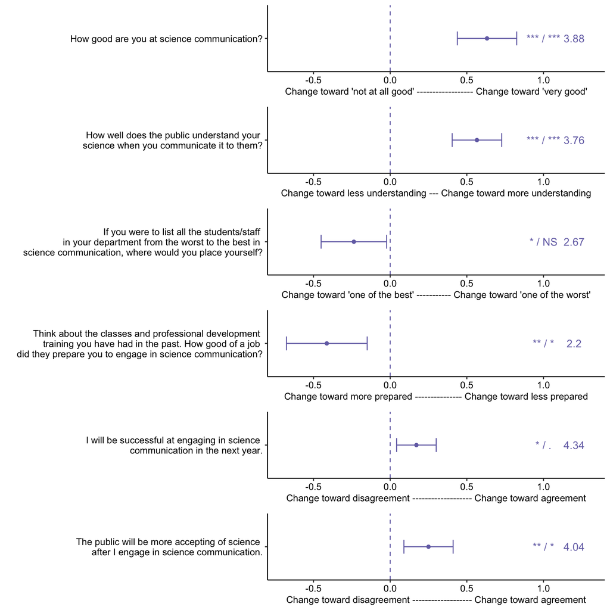

```r
pre_post_14_2_selected <- pre_post_14_2 %>%
  mutate(change = post_answer - pre_answer) %>%
  group_by(question_id, question) %>%
  summarize(mean_change = mean(change),
            se_change = plotrix::std.error(change)) %>%
  mutate(y = 1.2,
         y2 = 1,
         post_mean = round(mean(pre_post_14_2$post_answer), 2),
         stats = "** / *",
         question = "The public will be more accepting of science \nafter I engage in science communication.") %>%
  ggplot() +
    geom_point(aes(x = mean_change, y = question), color = "#7570b3") +
    geom_errorbar(aes(xmax = mean_change + 1.96 * se_change, xmin = mean_change - 1.96 * se_change,
                      y = question), width = 0.25, color = "#7570b3") +
    geom_vline(xintercept = 0, linetype = "dashed", color = "#7570b3") +
    geom_text(aes(x = y2, y = question, label = stats), size = 4, color = "#7570b3") +
    geom_text(aes(x = y, y = question, label = post_mean), size = 4, color = "#7570b3") +
    scale_x_continuous(limits = c(-0.7, 1.3), breaks = c(seq(-0.5, 1, 0.5))) +
    ylab("") +
    xlab("Change toward disagreement ------------------- Change toward agreement") +
    theme_classic() +
    theme(legend.position = "none",
          axis.text.y = element_text(size = 10, color = "black"),
          axis.text.x = element_text(size = 10, color = "black"),
          axis.title.x = element_text(size = 10, color = "black"))


plot_grid(pre_post_10_selected, pre_post_11_selected, pre_post_12_selected, pre_post_13_selected,
          pre_post_14_1_selected, pre_post_14_2_selected, ncol=1, align="v")
```

**Participants’ reported an increase in perceived abilities in science communication.**

#### Impact on Attitudes for Spiders

*Lastly, I queried the post-training survey responses related to attitudes toward spiders, as a key part of this training involved engaging the public about research on spiders.*

```sql
SELECT posttest.recipient_id, posttest.question_id, question, answer_type,
  definition_1, definition_2, definition_3, definition_4, definition_5, answer
FROM training.posttest
JOIN training.questions
ON posttest.question_id = questions.question_id
WHERE posttest.question_id LIKE 'post26%';
```

Only showing the first 3 rows.

| recipient_id | question_id | question | answer_type | definition_1 | definition_2 | definition_3 | definition_4 | definition_5 | answer |
| --- | --- | --- | --- | --- | --- | --- | --- | --- | --- |
| 24 | post26_1 | I would like to read more about spiders. | Level of Agreement | Strongly disagree | Somewhat disagree | Neither agree nor disagree | Somewhat agree | Strongly agree | 5 |
| 24 | post26_2 | I would like to know more about spiders. | Level of Agreement | Strongly disagree | Somewhat disagree | Neither agree nor disagree | Somewhat agree | Strongly agree | 5 |
| 24 | post26_3 | I would like to know more about how scientists study spiders. | Level of Agreement | Strongly disagree | Somewhat disagree | Neither agree nor disagree | Somewhat agree | Strongly agree | 5 |

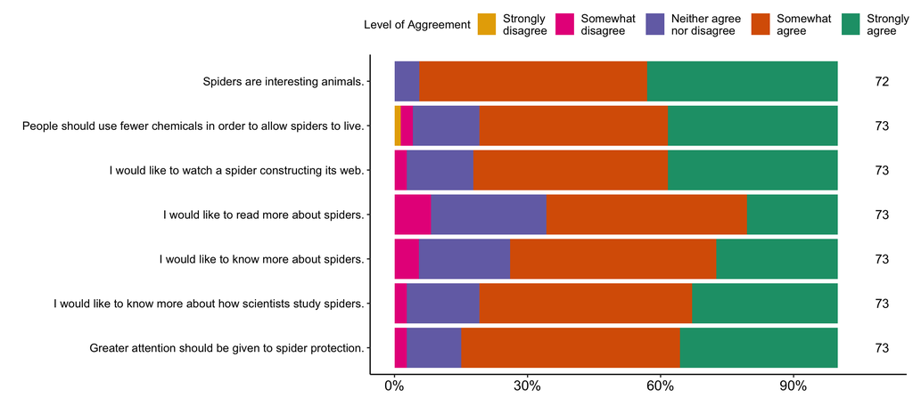

```r
six_colors = c("#1b9e77", "#e6ab02", "#d95f02", "#7570b3", "#e7298a", "#66a61e")

spider_attitudes <- spider_attitudes %>%
  filter(answer != "NULL") %>%
  mutate(answer = ifelse(answer == 1, "Strongly \ndisagree",
                  ifelse(answer == 2, "Somewhat \ndisagree",
                  ifelse(answer == 3, "Neither agree \nnor disagree",
                  ifelse(answer == 4, "Somewhat \nagree",
                  ifelse(answer == 5, "Strongly \nagree", "NA"))))),
         answer = fct_relevel(answer, "Strongly \nagree", "Somewhat \nagree",
                              "Neither agree \nnor disagree", "Somewhat \ndisagree",
                              "Strongly \ndisagree")) %>%
  group_by(question, question_id, answer) %>%
  count() %>%
  mutate(response = n) %>%
  dplyr::select(question_id, question, answer, response)

sum_spider_attitudes <- spider_attitudes %>%
  group_by(question) %>%
  summarize(total = sum(response)) %>%
  mutate(y = 1.1)

ggplot() +
    geom_bar(aes(x = response, y = question, fill = answer),
             position = "fill", stat = "identity", data = spider_attitudes) +
    geom_text(aes(x = y, y = question, label = total), data = sum_spider_attitudes) +
    scale_x_continuous(labels = scales::percent) +
    scale_fill_manual("Level of Aggreement",
                 values = five_colors) +
    xlab("") +
    ylab("") +
    theme_classic() +
    theme(legend.position = "top",
          axis.text.x = element_text(size = 12, color = "black"),
          axis.title.y = element_text(size = 12, color = "black"),
          axis.text.y = element_text(size = 10, color = "black"),
          legend.text = element_text(size = 10, color = "black"),
          legend.title = element_text(size = 10, color = "black")) +
    guides(fill = guide_legend(reverse=TRUE))
```

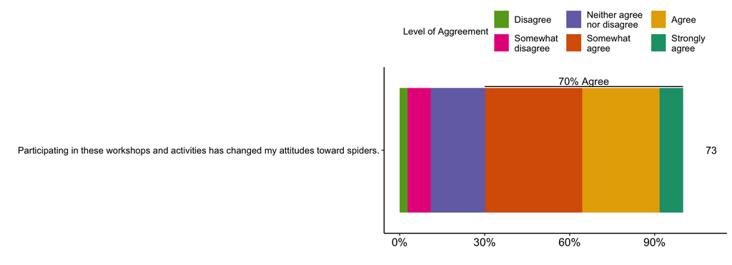

```r
change_spider_attitudes <- change_spider_attitudes %>%
  filter(answer != "NULL") %>%
  mutate(answer = ifelse(answer == 1, "Strongly \ndisagree",
                  ifelse(answer == 2, "Disagree",
                  ifelse(answer == 3, "Somewhat \ndisagree",
                  ifelse(answer == 4, "Neither agree \nnor disagree",
                  ifelse(answer == 5, "Somewhat \nagree",
                  ifelse(answer == 6, "Agree",
                  ifelse(answer == 7, "Strongly \nagree", "NA"))))))),
         answer = fct_relevel(answer, "Strongly \nagree", "Agree", "Somewhat \nagree",
                              "Neither agree \nnor disagree", "Somewhat \ndisagree",
                              "Disagree")) %>%
  group_by(question, question_id, answer) %>%
  count() %>%
  mutate(response = n) %>%
  dplyr::select(question_id, question, answer, response)

sum_change_spider_attitudes <- change_spider_attitudes %>%
  group_by(question) %>%
  summarize(total = sum(response)) %>%
  mutate(y = 1.1)

ggplot() +
    geom_bar(aes(x = response, y = factor(question), fill = answer),
             position = "fill", stat = "identity", data = change_spider_attitudes) +
    geom_text(aes(x = y, y = factor(question), label = total), data = sum_change_spider_attitudes) +
    annotate(geom = 'segment', y = 1.46,  x = 0.30, xend = 1, yend = 1.46) +
    annotate(geom = 'text', y = 1.5,  x = 0.65, label = "70% Agree") +
    scale_y_discrete() +
    scale_x_continuous(labels = scales::percent) +
    scale_fill_manual("Level of Aggreement",
                 values = six_colors) +
    xlab("") +
    ylab("") +
    theme_classic() +
    theme(legend.position = "top",
          axis.text.x = element_text(size = 12, color = "black"),
          axis.title.y = element_text(size = 12, color = "black"),
          axis.text.y = element_text(size = 10, color = "black"),
          legend.text = element_text(size = 10, color = "black"),
          legend.title = element_text(size = 10, color = "black")) +
    guides(fill = guide_legend(reverse=TRUE))
```

**Participants completed the training with a heightened curiosity about spiders, with 70% reporting that the training changed their attitude toward spiders.**

## Predicting Population Dynamics [R]

[**PUBLISHED**](https://doi.org/10.1007/s11252-023-01379-z)

- **Tech Stack**: R, QGIS, AIC Model Selection, Negative Binomial GLM, Geospatial Analysis, Predictive Modeling
- **Motivation**: To predict how environmental conditions in cities impact how spiders position themselves in their three-dimensional environment.
- **Impact**: Used satellite imagery and environmental datasets to inform conservation strategies and demonstrate the power of spatial data in ecological research. The findings point to a strong role of traffic disturbance in spider spatial patterns, which led to additional experiments (see Mapping City Noise Levels and Testing Web Vibration Transmission).
- **Github**: https://github.com/brandipessman/Agelenopsis_aggregation
- **Publication**: https://doi.org/10.1007/s11252-023-01379-z

### Negative Binomial GLMs

– Assessed spider abundance, aggregation, and web height at two distinct city habitats: a city center and a city forest.

*The graphs show the raw data (grey or transparent points) and the mean (orange/green points) and standard error (errorbars) predicted by the negative binomial generalized linear mixed models (GLMM). I chose this statistical test because the measurements were overdispersed count data.*

#### Abundance

**Spiders were more abundant in the city center than the city forest (*z<sub>20</sub>* = 3.13, *P* = 0.002).** Resources may be abundant in densely-populated and heavily-disturbed city centers where these spiders appear to thrive.

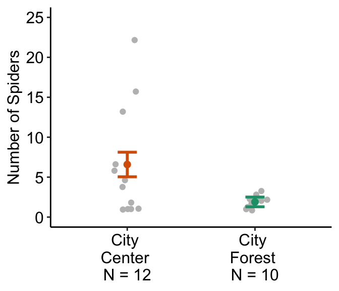

```r
# Negative Binomial Generalized Linear Model
spider.nb <- glm.nb(NumSpiders ~ Location, data = sites_wrangled)

# Calculate Model Predictions
nd <- data.frame(Location = factor(levels(sites_wrangled$Location)))
predictions <- augment(spider.nb, newdata = nd, se_fit = TRUE, type.predict = "response")
predictions <- predictions %>%
  rename("rate" = ".fitted", "SE" = ".se.fit")

# Plot the Model Predictions and Raw Data
ggplot(sites_wrangled, aes(x = Location, y = NumSpiders)) +
  geom_jitter(color = "grey", width = 0.1) +
  geom_point(aes(x = Location, y = rate, color = Location),
             size = 2, data = predictions) +
  geom_errorbar(aes(x = Location, ymin = rate - SE, ymax = rate + SE, color = Location),
                data = predictions, inherit.aes = FALSE, width = 0.15, size = 1) +
  scale_color_manual(values = c("Urban Center" = "#d95f02", "Urban Forest" = "#1b9e77")) +
  scale_x_discrete(labels=c("Urban Forest" = "City \nForest \nN = 10",
                            "Urban Center" = "City \nCenter \nN = 12")) +
  scale_y_continuous(limits = c(0, 25), breaks = c(0, 5, 10, 15, 20, 25)) +
  ylab("Number of Spiders") +
  theme_classic() +
  theme(text = element_text(size = 12),
        axis.text.x = element_text(colour = "black", size = 12),
        axis.text.y = element_text(colour = "black", size = 12),
        axis.title.x = element_blank(),
        legend.position = "none")
```

#### Aggregation

**Spiders were more aggregated - meaning a spider’s two nearest neighbors were closer - in the city center than the city forest (*z<sub>34</sub>* = -5.02, *P* < 0.001).** Fragmentation and smaller patch sizes in the city center may lead spiders to clump in areas of suitable habitat (e.g., abundant prey, structure for webs, reduced threats, etc.).

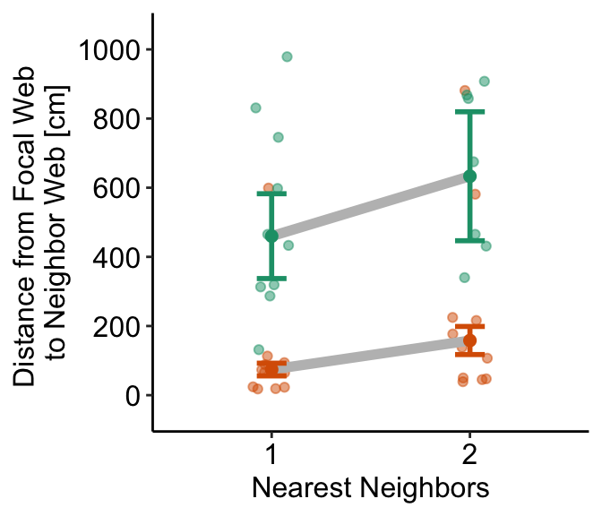

```r
# Negative Binomial Generalized Linear Mixed Model
dist.nb <- glmer.nb(round(RetreatDist, 0) ~ Location * factor(Neighbor) + (1 | ID),
                    data = neighbors_wrangled)

# Calculate Model Predictions
predictions <- expand.grid(Location = levels(factor(neighbors_wrangled$Location)),
                           Neighbor = levels(factor(neighbors_wrangled$Neighbor)))
predictions$response <- predict(dist.nb, newdata = predictions,
                                se.fit = TRUE, re.form = NA, type = "response")
BootFunc <- function(mm) {
    predict(mm, newdata = predictions, re.form = ~0, type = "response")
}
  #bigBoot_neighbors_nb <- bootMer(neighbor.nb, get_predictions, nsim = 1000)
bigBoot_neighbors_nb <- readRDS("bigBoot_neighbors_nb.Rds")
predSE <- t(apply(bigBoot_neighbors_nb$t, MARGIN = 2, FUN = sd, na.rm = TRUE))
predictions$SE <- predSE[1, ]

# Graph the Model Predictions and Raw Data
ggplot(neighbors_wrangled, aes(x = Neighbor, y = RetreatDist)) +
  geom_jitter(aes(color = Location), alpha = 0.5, width = 0.1) +
    geom_line(aes(x = Neighbor, y = response, group = Location),
              size = 2, data = predictions, color = "grey") +
  geom_point(aes(x = Neighbor, y = response, color = Location),
             size = 2, data = predictions) +
  geom_errorbar(aes(x = Neighbor, ymin = response - SE, ymax = response + SE,
                    color = Location),
                data = predictions, inherit.aes = FALSE, width = 0.15, size = 1) +
  scale_color_manual(values = c("Urban Center" = "#d95f02", "Urban Forest" = "#1b9e77")) +
  scale_x_discrete(labels=c("Urban Forest" = "Urban \nForest \nN = 10",
                            "Urban Center" = "Urban \nCenter \nN = 12")) +
  scale_y_continuous(limits = c(-50, 1050), breaks = c(0, 200, 400, 600, 800, 1000)) +
  xlab("Nearest Neighbors") +
  ylab("Distance from Focal Web \nto Neighbor Web [cm]") +
  theme_classic() +
  theme(text = element_text(size = 12),
        axis.text.x = element_text(colour = "black", size = 12),
        axis.text.y = element_text(colour = "black", size = 12),
        legend.position = "none")
```

#### Web Height

**Spider webs were lower in the city center than the city forest (*z<sub>128</sub>* = -2.44, *P* = 0.015).** Perhaps spiders build webs lower in the city center to capture different types of prey or because frequenct lawn maintenance forces lower webs. On the other hand, city forest spiders may build higher to avoid destruction by small mammals.

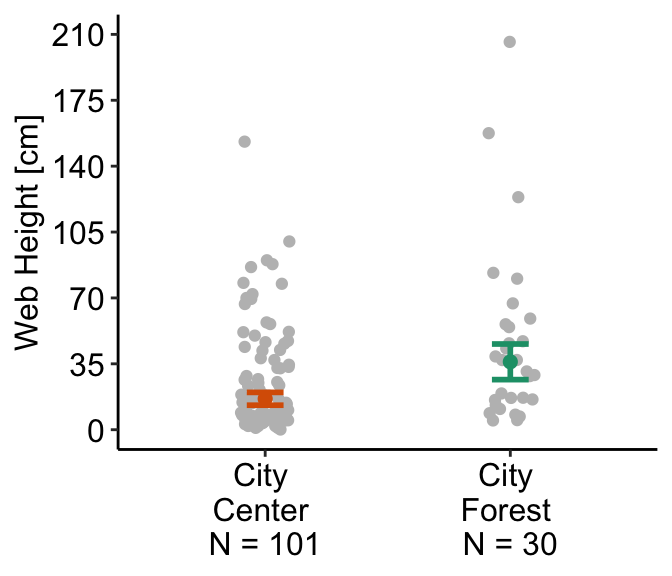

```r
# Negative Binomial Generalized Linear Mixed Model
height.nb <- glmer.nb(round(RetreatHeight, 0) ~ Location + (1 | ID), data = webs_wrangled)

# Calculate Model Predictions
predictions <- expand.grid(Location = levels(factor(webs_wrangled$Location)))
predictions$response <- predict(height.nb, newdata = predictions,
                                se.fit = TRUE, re.form = NA, type = "response")
  #bigBoot_height_nb <- bootMer(height.nb, BootFunc, nsim = 1000)
bigBoot_height_nb <- readRDS("bigBoot_height_nb.Rds")
predSE <- t(apply(bigBoot_height_nb$t, MARGIN = 2, FUN = sd))
predictions$SE <- predSE[1, ]

# Graph Model Predictions and Raw Data
ggplot(webs_wrangled, aes(x = Location, y = RetreatHeight)) +
  geom_jitter(color = "grey", width = 0.1) +
  geom_point(aes(x = Location, y = response, color = Location),
             size = 2, data = predictions) +
  geom_errorbar(aes(x= Location, ymin = response - SE, ymax = response + SE, color = Location),
                data = predictions, inherit.aes = FALSE, width = 0.15, size = 1) +
    scale_color_manual(values = c("Urban Center" = "#d95f02", "Urban Forest" = "#1b9e77")) +
    scale_x_discrete(labels=c("Urban Forest" = "City \nForest \nN = 30",
                              "Urban Center" = "City \nCenter \nN = 101")) +
    scale_y_continuous(limits = c(0, 210), breaks = c(0, 35, 70, 105, 140, 175, 210)) +
    ylab("Web Height [cm]") +
    theme_classic() +
    theme(text = element_text(size = 12),
          axis.text.x = element_text(colour = "black", size = 12),
          axis.text.y = element_text(colour = "black", size = 12),
          axis.title.x = element_blank(),
          legend.position = "none")
```

### AIC Model Selection

– Gathered environmental variables suspected to impact spider distributions in cities.

- Plant species richness - the number of unique plant species in a 10m-radius of a spider web

*Justification: The focal system needs plant structure for web construction.*

- Road- and highway-traffic impact - the daily average number of cars that pass on the nearest road or highway

*Justification: Vibrations produced by traffic may disturb spider senses.*

– Wrote a function, that takes the response variable as the input, to perform Akaike Information Criteria (AIC) model selection for identifying the environmental variables that best predict spider spatial patterns.

*Click the button to reveal the code for the function.*

```r
library(MuMIn) # to run the dredge function
library(tidyverse) # for wrangling
library(MASS) # negative binomial tests

aic_selection <- function(y_var, data) {
  # List predictors for each subset
  predictors_overall <- c("log_TotalSub", "log_tdr", "log_tdh")
  predictors_forest <- c("tree100m", "log_TotalSub", "log_tdh", "log_patch", "log_tdr")
  predictors_center <- c("log_TotalSub", "log_tdr", "log_tdh", "spec_rad", "log_patch", "road_length_m")

  # create subsets of data
  data_overall <- data
  data_forest <- data %>%
    filter(Location == "Urban Forest")
  data_center <- data %>%
    filter(Location == "Urban Center")

  # Performing glm and dredge
  run_analysis <- function(predictors, y_var, data_subset) {

    formula <- as.formula(paste(y_var, "~", paste(predictors, collapse = " + ")))

    # fit the global model
    global <- glm.nb(formula, data = data_subset)

    # Run dredge for model selection
    options(na.action = "na.fail") # Required for dredge to run
    model_dredge <- dredge(global, beta = "none", evaluate = TRUE, rank = AICc)
    options(na.action = "na.omit") # Set back to default

    # Models within 2 delta AIC
    model_selection <- model.sel(model_dredge)
    model_selection <- model_selection %>%
      filter(delta < 2)

    # Get the top model
    top_model <- get.models(model_dredge, subset = 1)[[1]]

    # Extract the summary of the top model
    model_summary <- summary(top_model)

    # Extract coefficient table (including standard errors)
    info <- coef(model_summary)

    # Extract exponentiated coefficients (and standard errors) for all predictors
    coeffs <- list()
    for (var in predictors) {
      if (var %in% rownames(info)) {
        coeffs[[var]] <- c(exp(info[var, 1]), exp(info[var, 2]))  # Exponentiated coefficients
      } else {
        coeffs[[var]] <- NA  # Handle case where the predictor is not in the top model
      }
    }

    # Calculate R squared value
    r_squared <- with(model_summary, 1 - deviance / null.deviance)

    # Check VIF for multicollinearity
    # Check VIF for multicollinearity, only if there are more than 1 predictor
    vif_values <- if (length(coef(top_model)) > 2) {
      car::vif(top_model)
    } else {
      NA  # VIF cannot be computed for models with fewer than 2 predictors
    }
    # return the results as a list
    return(list(
      model_summary = model_summary,
      r_squared = r_squared,
      model_selection = model_selection,
      vif_values = vif_values,
      coefficients = coeffs
    ))
  }

  # Run the analysis for each subset
  overall_results <- run_analysis(predictors_overall, y_var, data_overall)
  forest_results <- run_analysis(predictors_forest, y_var, data_forest)
  center_results <- run_analysis(predictors_center, y_var, data_center)

  # Return results for all three analyses
  return(list(
    overall = overall_results,
    forest = forest_results,
    center = center_results
  ))

}
```

#### Abundance

Disturbances from road-traffic did not significantly predict spider abundance across sites, as it was removed from the global model during model selection procedures.

```r
# Global Model
global <- glm.nb(NumSpiders ~ log_TotalSub + log_tdr + log_tdh, data = sites_wrangled)
summary_global <- data.frame(coef(summary(global)))

# Format the Table
rownames(summary_global) <- c("(Intercept)", "Plant Species Richness", "Road-Traffic Impact", "Highway-Traffic Impact")
summary_global <- summary_global %>%
  mutate(Pr...z.. = round(Pr...z.., digits = 3),
         Pr...z.. = ifelse(Pr...z.. == 0, "< 0.001", Pr...z..),
         Pr...z.. = ifelse(Pr...z.. < 0.001, paste0(Pr...z.., "***"),
                   ifelse(Pr...z.. < 0.01, paste0(Pr...z.., "**"),
                   ifelse(Pr...z.. < 0.05, paste0(Pr...z.., "*"), Pr...z..))))
colnames(summary_global) <- c("Estimate", "Std. Error", "z-value", "P-value")

# Make the Table
kable(summary_global, digits = 3, caption = "Global Model Summary") %>%
  kable_classic() %>%
  kable_styling(full_width = FALSE, position = "center")
```

Global Model Summary

|  | Estimate | Std. Error | z-value | P-value |
| --- | --- | --- | --- | --- |
| (Intercept) | 6.985 | 1.835 | 3.807 | < 0.001*** |
| Plant Species Richness | -0.973 | 0.222 | -4.385 | < 0.001*** |
| Road-Traffic Impact | -0.061 | 0.119 | -0.515 | 0.607 |
| Highway-Traffic Impact | -1.014 | 0.390 | -2.604 | 0.009** |

```r
# Perform Model Selection
options(na.action = "na.fail")
model_dredge <- dredge(global, beta = "none", evaluate = T, rank = AICc)
options(na.action = "na.omit")
top_model_spiders_o <- get.models(model_dredge, subset = 1)[[1]]
summary_spider <- data.frame(coef(summary(top_model_spiders_o)))

# Format the Table
rownames(summary_spider) <- c("(Intercept)", "Highway-Traffic Impact", "Plant Species Richness")
summary_spider <- summary_spider %>%
  mutate(Pr...z.. = round(Pr...z.., digits = 3),
         Pr...z.. = ifelse(Pr...z.. == 0, "< 0.001", Pr...z..),
         Pr...z.. = ifelse(Pr...z.. < 0.001, paste0(Pr...z.., "***"),
                   ifelse(Pr...z.. < 0.01, paste0(Pr...z.., "**"),
                   ifelse(Pr...z.. < 0.05, paste0(Pr...z.., "*"), Pr...z..))))
colnames(summary_spider) <- c("Estimate", "Std. Error", "z-value", "P-value")

# Make the Table
kable(summary_spider, digits = 3, caption = "Top Model Summary") %>%
  kable_classic() %>%
  kable_styling(full_width = FALSE, position = "center")
```

Top Model Summary

|  | Estimate | Std. Error | z-value | P-value |
| --- | --- | --- | --- | --- |
| (Intercept) | 6.404 | 1.568 | 4.085 | < 0.001*** |
| Highway-Traffic Impact | -0.950 | 0.376 | -2.528 | 0.011* |
| Plant Species Richness | -0.940 | 0.217 | -4.325 | < 0.001*** |

**Spider abundance was negatively impacted by more unique plant species and higher traffic disturbance from highways.** Sites with lower plant diversity may have few plant species that are highly preferred, leading to higher spider abundance. Traffic, especially on heavily-traveled routes like highways, can produce noise that disturbs spider senses.

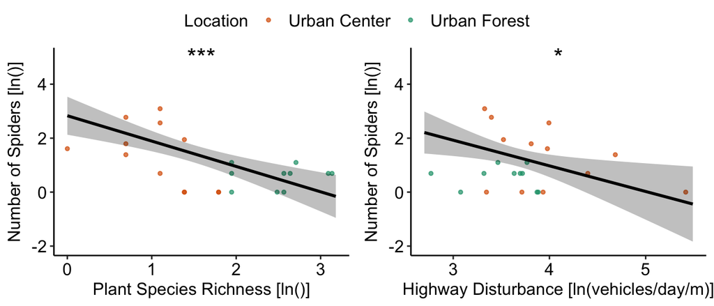

```r
coloro = "black"

# Get the Model Predictions - Plant Species Richness
nd <- data.frame(log_TotalSub = seq(0, 3.2, 0.03),
                 log_tdh = mean(sites_wrangled$log_tdh))
predicted.distance <- augment(top_model_spiders_o, newdata = nd, se_fit = TRUE)

# Graph Plant Species Richness
spiders_plant <- ggplot(sites_wrangled, aes(x = log_TotalSub, y = log(NumSpiders))) +
  geom_point(aes(color = Location),
             alpha = 0.7, size = 1) +
  geom_line(aes(x = log_TotalSub, y = .fitted),
            size = 1, color = coloro, data = predicted.distance) +
  geom_ribbon(aes(x = log_TotalSub,
                  ymin = .fitted - 1.96 * .se.fit, ymax = .fitted + 1.96 * .se.fit),
              fill = coloro, data = predicted.distance, inherit.aes = FALSE, alpha = 0.25) +
  scale_y_continuous(limits = c(-2, 5), breaks = c(-2, 0, 2, 4)) +
  scale_color_manual(values = c("Urban Center" = "#d95f02", "Urban Forest" = "#1b9e77")) +
  xlab("Plant Species Richness [ln()]") +
  ylab("Number of Spiders [ln()]") +
  theme_classic() +
  theme(text = element_text(size = 12),
        legend.text = element_text(size = 12),
        axis.text.x = element_text(colour = "black", size = 12),
        axis.text.y = element_text(colour = "black", size = 12),
        legend.position = "top") +
    annotate(geom = "text", x = min(predicted.distance$log_TotalSub) +
               diff(range(predicted.distance$log_TotalSub))/2,
             y = 5, label = "***", color = "black", size = 6)

# Get Model Predictions - Highway-Traffic Impact
nd <- data.frame(log_TotalSub = mean(sites_wrangled$log_TotalSub),
                 log_tdh = seq(2.7, 5.5, 0.03))
predicted.distance <- augment(top_model_spiders_o, newdata = nd, se_fit = TRUE)

# Graph Highway-Traffic Impact
spiders_tdh <- ggplot(sites_wrangled, aes(x = log_tdh, y = log(NumSpiders))) +
  geom_point(aes(color = Location),
             alpha = 0.7, size = 1) +
  geom_line(aes(x = log_tdh, y = .fitted),
            size = 1,color = coloro, data = predicted.distance) +
  geom_ribbon(aes(x = log_tdh,
                  ymin = .fitted - 1.96 * .se.fit, ymax = .fitted + 1.96 * .se.fit),
              fill = coloro, data = predicted.distance, inherit.aes = FALSE, alpha = 0.25) +
  scale_y_continuous(limits = c(-2, 5), breaks = c(-2, 0, 2, 4)) +
  scale_x_continuous(breaks = c(3, 4, 5)) +
  scale_color_manual(values = c("Urban Center" = "#d95f02", "Urban Forest" = "#1b9e77")) +
  xlab("Highway Disturbance [ln(vehicles/day/m)]") +
  ylab("Number of Spiders [ln()]") +
  theme_classic() +
  theme(text = element_text(size = 12),
        legend.text = element_text(size = 12),
        axis.text.x = element_text(colour = "black", size = 12),
        axis.text.y = element_text(colour = "black", size = 12),
        legend.position = "top") +
  annotate(geom = "text", x = min((predicted.distance$log_tdh)) +
             diff(range((predicted.distance$log_tdh)))/2,
           y = 5, label = "*", color = "black", size = 6)

ggarrange(spiders_plant, spiders_tdh, ncol = 2, common.legend = TRUE)
```

#### Aggregation

Traffic disturbances (from neither roads nor highways) did not significantly predict spider aggregations, as these predictors were removed from the global model during model selection procedures.

```r
nearest <- neighbors_wrangled %>%
  filter(Web == "W002")

# Global Model
global <- glm.nb(round(RetreatDist, 0) ~ log_TotalSub + log_tdr + log_tdh, data = nearest)
summary_global <- data.frame(coef(summary(global)))

# Format the Table
rownames(summary_global) <- c("(Intercept)", "Plant Species Richness", "Road-Traffic Impact", "Highway-Traffic Impact")
summary_global <- summary_global %>%
  mutate(Pr...z.. = round(Pr...z.., digits = 3),
         Pr...z.. = ifelse(Pr...z.. == 0, "< 0.001", Pr...z..),
         Pr...z.. = ifelse(Pr...z.. < 0.001, paste0(Pr...z.., "***"),
                   ifelse(Pr...z.. < 0.01, paste0(Pr...z.., "**"),
                   ifelse(Pr...z.. < 0.05, paste0(Pr...z.., "*"), Pr...z..))))
colnames(summary_global) <- c("Estimate", "Std. Error", "z-value", "P-value")

# Make the Table
kable(summary_global, digits = 3, caption = "Global Model Summary") %>%
  kable_classic() %>%
  kable_styling(full_width = FALSE, position = "center")
```

Global Model Summary

|  | Estimate | Std. Error | z-value | P-value |
| --- | --- | --- | --- | --- |
| (Intercept) | 4.142 | 2.002 | 2.069 | 0.039* |
| Plant Species Richness | 0.682 | 0.260 | 2.620 | 0.009** |
| Road-Traffic Impact | -0.231 | 0.149 | -1.555 | 0.12 |
| Highway-Traffic Impact | 0.334 | 0.395 | 0.847 | 0.397 |

```r
# Perform Model Selection
options(na.action = "na.fail")
model_dredge <- dredge(global, beta = "none", evaluate = T, rank = AICc)
options(na.action = "na.omit")
top_model_neighbor_o <- get.models(model_dredge, subset = 1)[[1]]
summary_nearest <- data.frame(coef(summary(top_model_neighbor_o)))

# Format the Table
rownames(summary_nearest) <- c("(Intercept)", "Plant Species Richness")
summary_nearest <- summary_nearest %>%
  mutate(Pr...z.. = round(Pr...z.., digits = 3),
         Pr...z.. = ifelse(Pr...z.. == 0, "< 0.001", Pr...z..),
         Pr...z.. = ifelse(Pr...z.. < 0.001, paste0(Pr...z.., "***"),
                   ifelse(Pr...z.. < 0.01, paste0(Pr...z.., "**"),
                   ifelse(Pr...z.. < 0.05, paste0(Pr...z.., "*"), Pr...z..))))
colnames(summary_nearest) <- c("Estimate", "Std. Error", "z-value", "P-value")

# Make the Table
kable(summary_nearest, digits = 3, caption = "Top Model Summary") %>%
  kable_classic() %>%
  kable_styling(full_width = FALSE, position = "center")
```

Top Model Summary

|  | Estimate | Std. Error | z-value | P-value |
| --- | --- | --- | --- | --- |
| (Intercept) | 4.460 | 0.467 | 9.549 | < 0.001*** |
| Plant Species Richness | 0.633 | 0.241 | 2.621 | 0.009** |

**Spiders were more aggregated at sites with less diverse plants.** Perhaps this spider prefers a certain plant, or type of plant, especially in the city center where plants are clumped in space.

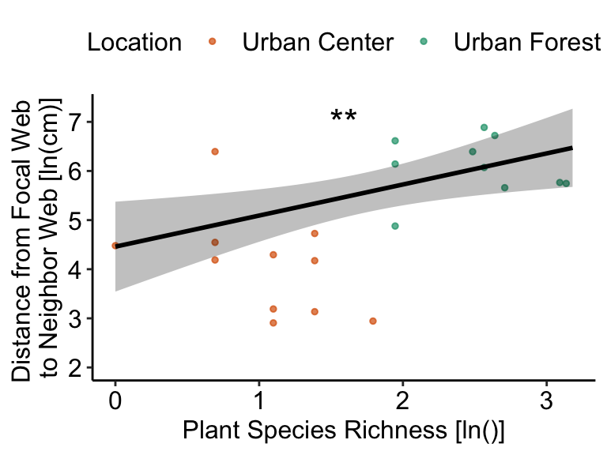

```r
# Get Model Predictions
nd <- data.frame(log_TotalSub = seq(0, 3.2, 0.03))
predicted.distance <- augment(top_model_neighbor_o,
                              newdata = nd,
                              se_fit = TRUE)

# Graph Plant Species Richness
ggplot(nearest, aes(x = log_TotalSub, y = log(RetreatDist))) +
  geom_point(aes(color = Location),
             alpha = 0.7, size = 1) +
  geom_line(aes(x = log_TotalSub, y = .fitted),
            size = 1, color = coloro, data = predicted.distance) +
  geom_ribbon(aes(x = log_TotalSub,
                  ymin = .fitted - 1.96 * .se.fit, ymax = .fitted + 1.96 * .se.fit),
              fill = coloro, data = predicted.distance, inherit.aes = FALSE, alpha = 0.25) +
  scale_y_continuous(limits = c(2, 7.3), breaks = c(2, 3, 4, 5, 6, 7)) +
  scale_color_manual(values = c("Urban Center" = "#d95f02", "Urban Forest" = "#1b9e77")) +
  xlab("Plant Species Richness [ln()]") +
  ylab("Distance from Focal Web \nto Neighbor Web [ln(cm)]") +
  theme_classic() +
  theme(text = element_text(size = 12),
        axis.text.x = element_text(colour = "black", size = 12),
        legend.text = element_text(size = 12),
        axis.text.y = element_text(colour = "black", size = 12),
        legend.position = "top") +
  annotate(geom = "text", x = min(predicted.distance$log_TotalSub) +
             diff(range(predicted.distance$log_TotalSub))/2,
           y = 7, label = "**", color = "black", size = 6)
```

#### Web Height

Disturbances from highway-traffic did not significantly predict spider web height across sites, as it was removed from the global model during model selection procedures.

```r
# Global Model
global <- glmer.nb(round(RetreatHeight, 0) ~ log_TotalSub + log_tdr + log_tdh + (1 | ID),
                   data = webs_wrangled)
summary_global <- data.frame(coef(summary(global)))

# Format the Table
rownames(summary_global) <- c("(Intercept)", "Plant Species Richness", "Road-Traffic Impact", "Highway-Traffic Impact")
summary_global <- summary_global %>%
  mutate(Pr...z.. = round(Pr...z.., digits = 3),
         Pr...z.. = ifelse(Pr...z.. == 0, "< 0.001", Pr...z..),
         Pr...z.. = ifelse(Pr...z.. < 0.001, paste0(Pr...z.., "***"),
                   ifelse(Pr...z.. < 0.01, paste0(Pr...z.., "**"),
                   ifelse(Pr...z.. < 0.05, paste0(Pr...z.., "*"), Pr...z..))))
colnames(summary_global) <- c("Estimate", "Std. Error", "z-value", "P-value")

# Make the Table
kable(summary_global, digits = 3, caption = "Global Model Summary") %>%
  kable_classic() %>%
  kable_styling(full_width = FALSE, position = "center")
```

Global Model Summary

|  | Estimate | Std. Error | z-value | P-value |
| --- | --- | --- | --- | --- |
| (Intercept) | 4.514 | 1.446 | 3.121 | 0.002** |
| Plant Species Richness | 0.413 | 0.182 | 2.267 | 0.023* |
| Road-Traffic Impact | -0.198 | 0.103 | -1.924 | 0.054 |
| Highway-Traffic Impact | -0.300 | 0.287 | -1.044 | 0.296 |

```r
# Perform Model Selection
options(na.action = "na.fail")
model_dredge <- dredge(global, beta = "none", evaluate = TRUE, rank = AICc)
options(na.action = "na.omit")
top_model_height_o <- get.models(model_dredge, subset = 1)[[1]]
summary_height <- data.frame(coef(summary(top_model_height_o)))

# Format the Table
rownames(summary_height) <- c("(Intercept)", "Road-Traffic Impact", "Plant Species Richness")
summary_height <- summary_height %>%
  mutate(Pr...z.. = round(Pr...z.., digits = 3),
         Pr...z.. = ifelse(Pr...z.. == 0, "< 0.001", Pr...z..),
         Pr...z.. = ifelse(Pr...z.. < 0.001, paste0(Pr...z.., "***"),
                   ifelse(Pr...z.. < 0.01, paste0(Pr...z.., "**"),
                   ifelse(Pr...z.. < 0.05, paste0(Pr...z.., "*"), Pr...z..))))
colnames(summary_height) <- c("Estimate", "Std. Error", "z-value", "P-value")

# Make the Table
kable(summary_height, digits = 3, caption = "Top Model Summary") %>%
  kable_classic() %>%
  kable_styling(full_width = FALSE, position = "center")
```

Top Model Summary

|  | Estimate | Std. Error | z-value | P-value |
| --- | --- | --- | --- | --- |
| (Intercept) | 3.145 | 0.614 | 5.123 | < 0.001*** |
| Road-Traffic Impact | -0.174 | 0.102 | -1.715 | 0.086 |
| Plant Species Richness | 0.492 | 0.168 | 2.938 | 0.003** |

**Webs were constructed higher at sites with more diverse plants. Web height was not impacted by road-traffic.** Sites with more diverse plants might provide opportunities for higher webs.

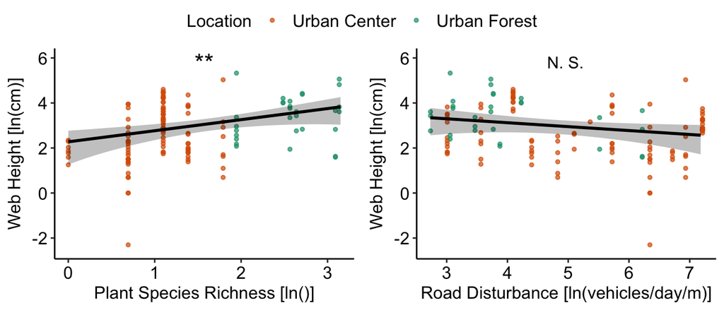

```r
# Get Model Predictions
predictions <- expand.grid(log_TotalSub = seq(0, 3.15, 0.03),
                           log_tdr = mean(webs_wrangled$log_tdr))
predictions$response <- predict(top_model_height_o, newdata = predictions,
                                se.fit = TRUE, re.form = NA, type = "response")
  #bigBoot_height_overall_plant_nb <- bootMer(top_model_height_o, BootFunc, nsim = 1000)
bigBoot_height_overall_plant_nb <- readRDS("bigBoot_height_overall_plant_nb.Rds")
predSE <- t(apply(bigBoot_height_overall_plant_nb$t, MARGIN = 2, FUN = sd))
predictions$SE <- predSE[1, ]

# Graph Model Predictions - Plant Species Richness
height_plant <- ggplot(webs_wrangled, aes(x = log_TotalSub, y = log(RetreatHeight))) +
  geom_point(aes(color = Location),
             alpha = 0.7, size = 1) +
  geom_line(aes(x = log_TotalSub, y = log(response)),
            size = 1, color = coloro, data = predictions) +
  geom_ribbon(aes(x = log_TotalSub,
                  ymin = log(response - 1.96 * SE), ymax = log(response + 1.96 * SE)),
              fill = coloro, data = predictions, inherit.aes = FALSE, alpha = 0.25) +
  scale_y_continuous(limits = c(-2.5, 6), breaks = c(-2, 0, 2, 4, 6)) +
  scale_color_manual(values = c("Urban Center" = "#d95f02", "Urban Forest" = "#1b9e77")) +
  xlab("Plant Species Richness [ln()]") +
  ylab("Web Height [ln(cm)]") +
  theme_classic() +
  theme(text = element_text(size = 12),
        legend.text = element_text(size = 12),
        axis.text.x = element_text(colour = "black", size = 12),
        axis.text.y = element_text(colour = "black", size = 12),
        legend.position = "top") +
    annotate(geom = "text", x = min(predictions$log_TotalSub) +
               diff(range(predictions$log_TotalSub))/2,
             y = 5.8, label = "**", color = "black", size = 6)

# Get Model Predictions
predictions <- expand.grid(log_TotalSub = mean(webs_wrangled$log_TotalSub),
                           log_tdr = seq(2.73, 7.22, 0.05))
predictions$response <- predict(top_model_height_o, newdata = predictions,
                                se.fit = TRUE, re.form = NA, type = "response")
  #bigBoot_height_overall_tdr_nb <- bootMer(top_model_height_o, BootFunc, nsim = 1000)
bigBoot_height_overall_tdr_nb <- readRDS("bigBoot_height_overall_tdr_nb.Rds")
predSE <- t(apply(bigBoot_height_overall_tdr_nb$t, MARGIN = 2, FUN = sd))
predictions$SE <- predSE[1, ]

# Graph Model Predictions - Road-Traffic Impact
height_tdr <- ggplot(webs_wrangled, aes(x = log_tdr, y = log(RetreatHeight))) +
  geom_point(aes(color = Location),
             alpha = 0.7, size = 1) +
  geom_line(aes(x = log_tdr, y = log(response)),
            size = 1, color = coloro, data = predictions) +
  geom_ribbon(aes(x = log_tdr,
                  ymin = log(response - 1.96 * SE), ymax = log(response + 1.96 * SE)),
              fill = coloro, data = predictions, inherit.aes = FALSE, alpha = 0.25) +
  scale_y_continuous(limits = c(-2.5, 6), breaks = c(-2, 0, 2, 4, 6)) +
  scale_color_manual(values = c("Urban Center" = "#d95f02", "Urban Forest" = "#1b9e77")) +
  xlab("Road Disturbance [ln(vehicles/day/m)]") +
  ylab("Web Height [ln(cm)]") +
  theme_classic() +
  theme(text = element_text(size = 12),
        legend.text = element_text(size = 12),
        axis.text.x = element_text(colour = "black", size = 12),
        axis.text.y = element_text(colour = "black", size = 12),
        legend.position = "top") +
  annotate(geom = "text", x = min(predictions$log_tdr) + diff(range(predictions$log_tdr))/2,
           y = 5.8, label = "N. S.", color = "black", size = 4)

ggarrange(height_plant, height_tdr, ncol = 2, common.legend = TRUE)
```

### Geospatial Analysis with QGIS

– Used publicly available GIS layers to compare environmental conditions between city center (a) and city forest (b):

- National Land Cover Database - Impervious (building and pavement) Cover 2019
- Landsat-7 World Reference System-2 - Spectral Radiance 2020
- Visible Infrared Imaging Radiometer Suite (VIIRS) - Artificial Night Sky Radiance 2020

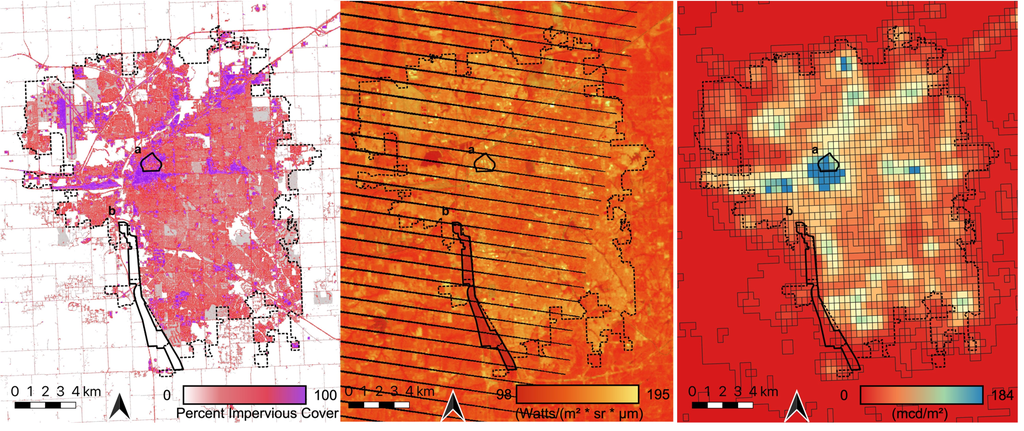

– Leveraged QGIS to calculate the average of each variable in a 100m-radius buffer around each site to use in further analyses.

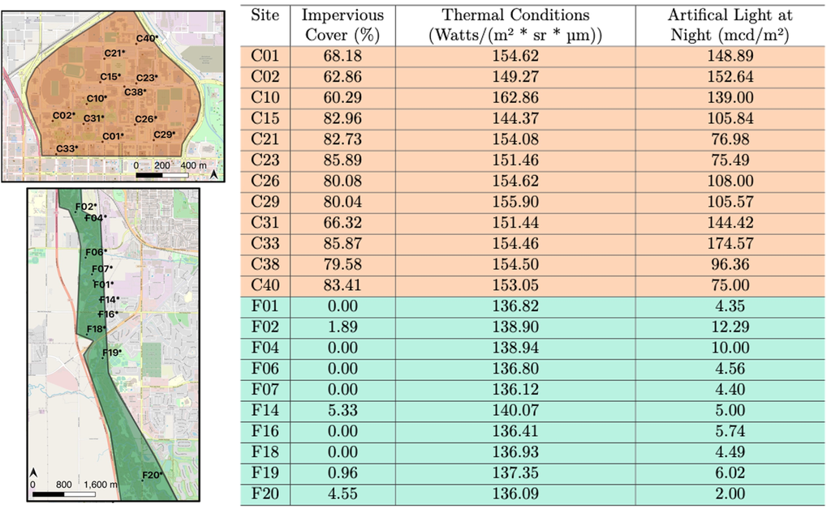

## Mapping City Noise Levels [R]

[**PUBLISHED**](https://doi.org/10.1111/eea.13487)

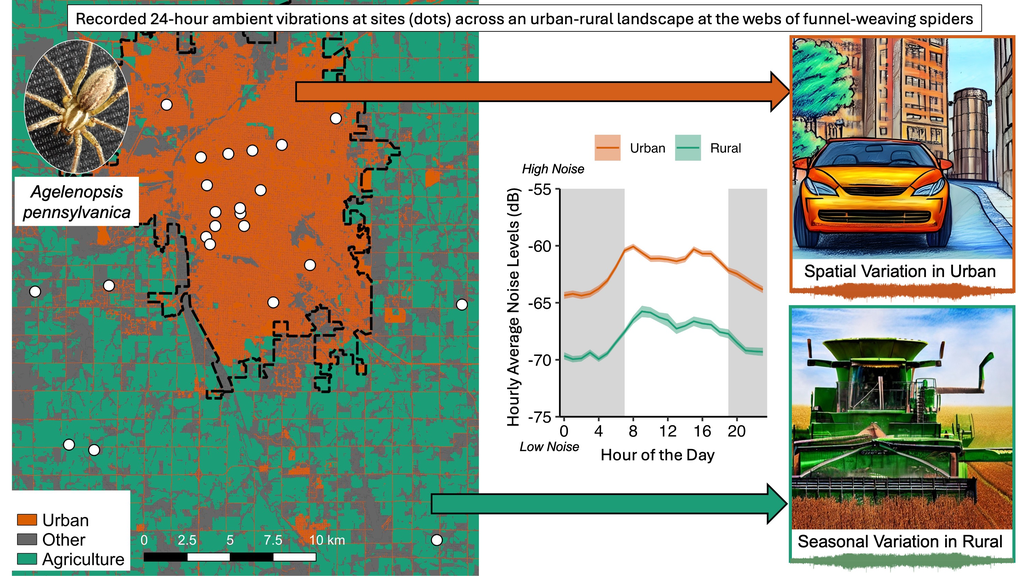

- **Tech Stack**: R, QGIS, Raven Pro, Principal Component Analysis, Linear Mixed-Effect Models, Time Series
- **Motivation**: To spatially and temporally quantify vibratory noise levels in cities experienced by a common city spider.
- **Impact**: Developed spatial and time series models, integrating GIS mapping and statistical modeling. Findings provide critical insights into noise pollution and its likely impact on diverse wildlife.
- **Github**: https://github.com/brandipessman/Vibratory_Noise
- **Publication**: https://doi.org/10.1111/eea.13487

### Spatial Noise Variation

**City spiders are more likely impacted by spatial variation in vibratory noise related to traffic than country spiders.**

#### Noise Map

– Recorded vibratory noise levels at 23 sites across urban (within city limits in shaded grey area) and rural (countryside) areas in Lincoln, Nebraska and mapped the daily average noise level for each site.

– Utilized the *ggmap* package in R to map the coordinates of the recording sites, integrating data about average noise levels at each site.

**Sites within city limits are noisier (yellow/pink/orange), especially those near major highways (black lines), than those in the countryside.**

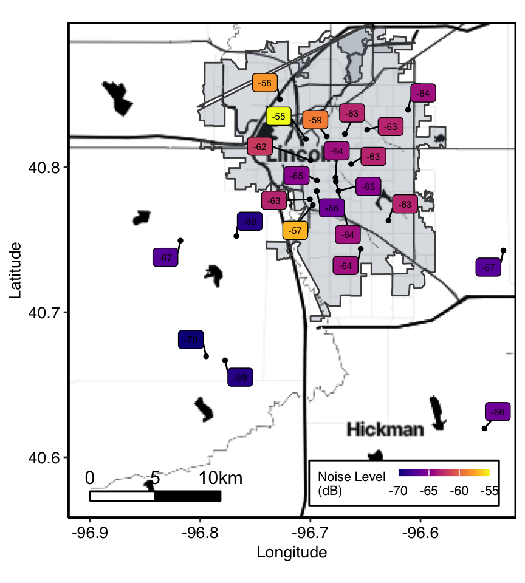

```r
# Get the Lincoln City Limits Outline
lincoln <- data.frame(read.table("lincoln_coordinates.txt", sep = "," , header = F)) %>%
  slice(10:2350) %>%
  separate(V1, c("extra", "longitude", "latitude"), " ") %>%
  mutate(longitude = as.numeric(longitude),
         latitude = as.numeric(latitude))

# Bring in Site Coordinates
sites <- read.csv("site_coordinates.csv", header = TRUE) %>%
  mutate(Site = Sites, .keep = "unused") %>%
  full_join(readRDS("siteavgl.rds"), by = "Site") %>%
  mutate(mean_leq = round(mean_leq),
         med_leq = round(med_leq)) %>%
  mutate(choice = ifelse(Site == "8A" | Site == "8B", "Urban",
                  ifelse(Site == "5A" | Site == "6C", "Rural", "Other")),
         choice = factor(choice),
         choice = fct_relevel(choice, "Rural", "Urban", "Other"))

# get background map
lancaster <- map_data("county") %>%
  subset(region == "nebraska") %>%
  subset(subregion == "lancaster")
lc_borders <- c(bottom   = min(lancaster$lat)  + 0.05,
                 top     = max(lancaster$lat)  - 0.13,
                 left    = min(lancaster$long) - 0.01,
                 right   = max(lancaster$long) - 0.05)
map <- get_stadiamap(lc_borders, zoom = 10, maptype = "stamen_toner")

# Make the Map
ggmap(map) +
  #add scalebar
  ggsn::scalebar(x.min = -96.9, x.max = -96.5,
                 y.min = 40.57, y.max = 40.899,
                 dist = 5, dist_unit = "km", transform = TRUE,
                 location = "bottomleft",
                 st.bottom = FALSE, box.color = c("black", "black"),
                 st.size = 4, border.size = 0.5, st.dist = 0.03) +
  #add Lincoln outline/shading
  geom_polygon(data = lincoln,
               aes(x = longitude, y = latitude),
               fill = "slategray", alpha = 0.25, color = "gray30") +
  # add sites and labels
  geom_point(data = sites,
             mapping = aes(x = Longitude, y = Latitude),
             pch=21, size = 1, fill = "black") +
  geom_label_repel(aes(x =Longitude, y = Latitude,
                       fill = mean_leq, label = mean_leq),
                   min.segment.length = 0.1, max.overlaps = Inf,
                   size = 2, data = sites) +
  scale_fill_viridis(name = "Noise Level \n(dB)", option = "C") +
  ylab("Latitude") + xlab("Longitude") +
  labs(fill = "Avg. Noise Level (dB)") +
  theme_classic() +
  theme(panel.border = element_rect(colour = "black", fill=NA, size=1),
        legend.position = c(0.75, 0.07),
        legend.direction = "horizontal",
        legend.background = element_rect(fill = "white",
                                  size = 0.5, linetype = "solid",
                                  colour ="black"),
        legend.key.height = unit(0.15, 'cm'),
        legend.key.width = unit(0.4, 'cm'),
        text = element_text(size = 10, color = "black", family = "sans"),
        axis.text = element_text(size = 10, color = "black", family = "sans"),
        legend.text = element_text(size = 8, family = "sans"),
        legend.title = element_text(size = 8, family = "sans"))
```

#### PCA

– Performed a Principal Component Analysis (PCA) in R to reduce dimensions of traffic disturbance variables:

- *Traffic Distance* - Distance to nearest road
- *Traffic* - Daily number of cars to pass on nearest road
- *Road Length* - Total road length in 100m-radius of recording site
- *Impervious* - Percent impervious (i.e., buildings, pavement) cover in 100m-radius

**Principal Component 1 includes contributions from all traffic disturbance variables and explains much of the variation (70.9%), making it a good indicator of traffic disturbance.** The horizontal divide between country (green) and city (orange) recording sites suggests that all city sites have a higher probability of being disturbed by traffic.

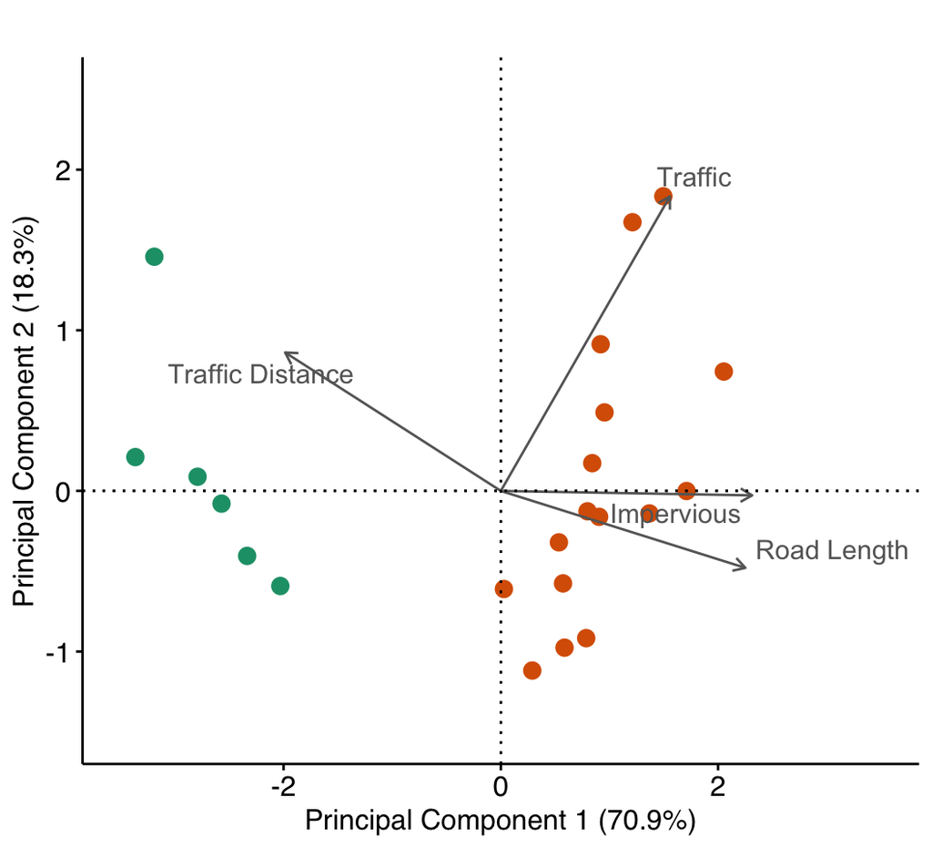

```r
# Wrangle the Data
pca <- read.table("pca_noise.txt", header = TRUE)
colnames(pca) <- c('Impervious','Road Distance','Traffic Distance', 'Traffic', 'Road Length', 'Traffic Impact', 'Category')
pca <- pca %>%
  filter(! Category == "Forest") %>%
  mutate(Category = fct_relevel(factor(Category), "Urban", "Rural"))
pca <- pca[, c(1, 3, 4, 5, 2, 6, 7)]

# Perform the PCA
site_pca <- PCA(pca[,1:4], graph = FALSE)

# Make the Graph
fviz_pca_biplot(site_pca,
                repel = TRUE,
                fill.ind = pca$Category,
                col.ind = pca$Category,
                palette = c("#D95F02", "#1B9E77"),
                label = "var",
                labelsize = 4,
                pointsize = 3,
                pointshape = 21,
                axes.linetype = "dotted",
                mean.point = FALSE,
                col.var = "grey40",
                xlab = "Principal Component 1 (70.9%)",
                ylab = "Principal Component 2 (18.3%)",
                title = "",
                ggtheme = theme_classic() +
                  theme(text = element_text(size = 12))) +
  xlim(-3.5, 3.5) +
  ylim(-1.5, 2.5) +
  theme(legend.position = "none",
        axis.text.x = element_text(colour = "black", size = 12,
                                   family = "sans"),
        axis.text.y = element_text(colour = "black", size = 12,
                                   family = "sans"),
        axis.title.x = element_text(colour = "black", size = 12,
                                    family = "sans"),
        axis.title.y = element_text(colour = "black", size = 12,
                                    family = "sans"))
```

#### LMM

– Used a linear mixed-effect model (LMM) to predict vibratory noise levels based on the level of potential traffic disturbance.

*Each point and errorbar represents the calculated mean and standard deviation of all recordings at a site on a particular substrate type (two substrate types were recorded at each site). The line and error ribbon represent the mean and standard error from the predictions of the LMM. The red points represent the single loudest and quietest recordings. I included site as a random effect because sites were represented more than once in the model.*

**Higher traffic disturbance correlated with elevated vibratory noise levels (*t-value* = 5.856, *N* = 295, *P* < 0.001).** Traffic likely contributes significantly to vibratory noise pollution.

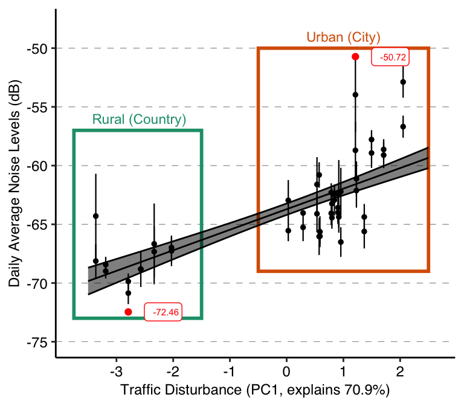

```r
# Wrangle Data
dayavgl <- readRDS("dayavgl.rds")
spatial_dayavgl <- dayavgl %>%
  ungroup() %>%
  dplyr::select(Site, Category, Substrate, Dim.1, Dim.2, mean_leq) %>%
  group_by(Site, Substrate, Category, Dim.1, Dim.2) %>%
  summarize(mean = mean(mean_leq),
            sd = sd(mean_leq))
highlights <- dayavgl %>%
  filter(mean_leq == max(dayavgl$mean_leq) |
           mean_leq == min(dayavgl$mean_leq)) %>%
  mutate(mean_leq = round(mean_leq, 2))

# Linear Mixed Model
dayavgl.lmer <- lmer(mean_leq ~ Dim.1 + (1|Site), data = dayavgl)

# Calculate Model Predictions
predictions <- expand.grid(Dim.1 = seq(-3.5, 2.5, 0.05))
predictions$response <- predict(dayavgl.lmer, newdata = predictions, se.fit = TRUE, re.form = NA, type = "response")
bigBoot_spatial <- readRDS("bigBoot_spatial.Rds")
predSE <- t(apply(bigBoot_spatial$t, MARGIN = 2, FUN = sd))
predictions$SE <- predSE[1, ]

# Graph Model Predictions and Raw Data
ggplot() +
  annotate("rect", xmin = -3.75, xmax = -1.5, ymin = -73, ymax = -57,
           alpha = 0.25, color = "#1B9E77", fill = NA, linewidth = 1) +
  annotate("rect", xmin = -0.5, xmax = 2.5, ymin = -69, ymax = -50,
           alpha = 0.25, color = "#D95F02", fill = NA, linewidth = 1) +
  annotate("text", x = 1, y = -49, color = "#D95F02",
           label = "Urban (City)", size = 3) +
  annotate("text", x = -2.6, y = -56, color = "#1B9E77",
           label = "Rural (Country)", size = 3) +
  geom_point(aes(x = Dim.1, y = mean),
             data = spatial_dayavgl, color = "black",
             position = position_dodge(width = 0.25), size = 1) +
  geom_errorbar(aes(x = Dim.1, ymax = mean + sd, ymin = mean - sd),
                width = 0, data = spatial_dayavgl, color = "black",
                position = position_dodge(width = 0.25), linewidth = 0.4) +
  geom_point(aes(x = Dim.1, y = mean_leq),
             color = "red", data = highlights) +
  geom_line(aes(x = Dim.1, y = response),
            data = predictions, color = "black") +
  geom_ribbon(aes(x = Dim.1, ymax = response + SE, ymin = response - SE),
              data = predictions, color = "black", fill = "black",
              alpha = 0.5) +
  geom_label_repel(aes(x = Dim.1, y = mean_leq, label = mean_leq),
                   color = "red", hjust = "right", data = highlights,
                   size = 2) +
  xlab("Traffic Disturbance (PC1, explains 70.9%)") +
  ylab("Daily Average Noise Levels (dB)") +
  scale_y_continuous(limits = c(-75, -48),
                     breaks = c(-75, -70, -65, -60, -55, -50)) +
  scale_x_continuous(limits = c(-3.75, 2.65),
                     breaks = c(-3, -2, -1, 0, 1, 2)) +
  theme_classic() +
  theme(text = element_text(size = 9, color = "black", family = "sans"),
        axis.text = element_text(size = 9, color = "black", family = "sans"),
        axis.title = element_text(size = 9, color = "black", family = "sans"),
        panel.grid.major.y = element_line(colour = "black",
                                          linetype = "dashed",
                                          linewidth = 0.1))
```

### Seasonal Noise Variation

**Country spiders are more likely to be impacted by seasonal variation in vibratory noise related to harvest activities than city spiders.**

#### Time Series

*The points and errorbars represent the calculated mean and standard deviation across all recordings on a particular visit. The lines and error ribbons represent the mean and standard error predicted from the LMM, which accounted for repeated testing at each site. The red points represent the single loudest and quietest recordings.*

**Vibratory noise levels tended to vary across the season (*χ2* = 7.360, *N* = 268, *P* = 0.061), driven mainly by changes in the third recording visit in rural areas.**

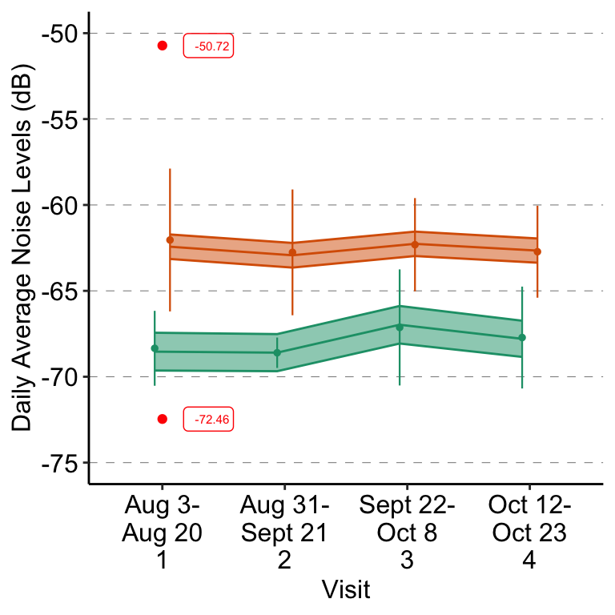

```r
# Linear Mixed Model
season.lmer <- lmer(mean_leq ~ Visit * Category + (1|Site),
                    data = dayavgl_2020)

# Calculate Model Predictions
predictions <- expand.grid(Visit = levels(factor(dayavgl_2020$Visit)),
                           Category = levels(factor(dayavgl_2020$Category)))
predictions$response <- predict(season.lmer, newdata = predictions,
                                se.fit = TRUE, re.form = NA,
                                type = "response")
bigBoot_season <- readRDS("bigBoot_season.Rds")
predSE <- t(apply(bigBoot_season$t, MARGIN = 2, FUN = sd))
predictions$SE <- predSE[1, ]

# New Labels
labs <- c("Visit 1: Aug 3-20",
          "Visit 2: Aug 31-Sept 21",
          "Visit 3: Sept 22-Oct 8",
          "Visit 4: Oct 12-23")
names(labs) <- c("1", "2", "3", "4")

group2v3 <- data.frame(x = c(2, 3),
                   y = c(-51, -51))

# Graph Model Predictions and Raw Data
ggplot() +
  geom_point(aes(x = Visit, y = mean, color = Category),
             data = season_dayavgl_2020, size = 1,
             position = position_dodge(width = 0.25)) +
  geom_errorbar(aes(x = Visit, ymax = mean + sd, ymin = mean - sd,
                    color = Category),
                data = season_dayavgl_2020, width = 0, linewidth = 0.4,
                position = position_dodge(width = 0.25)) +
  geom_point(aes(x = Visit, y = mean_leq),
             color = "red", data = highlights) +
  geom_line(aes(x = as.numeric(Visit), y = response,
                color = Category, group = Category),
            data = predictions, linewidth = 0.5,
            position = position_dodge(width = 0.25)) +
  geom_ribbon(aes(x = as.numeric(Visit), ymax = response + SE,
                  ymin = response - SE, color = Category,
                  fill = Category, group = Category),
              alpha = 0.5, data = predictions,
              position = position_dodge(width = 0.25)) +
  geom_label_repel(aes(x = Visit, y = mean_leq, label = mean_leq),
                   color = "red", hjust = "right", data = highlights,
                   size = 2) +
  xlab("Visit") +
  ylab("Daily Average Noise Levels (dB)") +
  scale_color_manual("Category", values = c("#1B9E77", "#D95F02"),
                     labels = c("Rural", "Urban")) +
  scale_fill_manual("Category", values = c("#1B9E77", "#D95F02"),
                     labels = c("Rural", "Urban")) +
  scale_x_discrete(labels=c("1" = "Aug 3-\nAug 20\n1",
                            "2" = "Aug 31-\nSept 21\n2",
                            "3" = "Sept 22-\nOct 8\n3",
                            "4" = "Oct 12-\nOct 23\n4")) +
  scale_y_continuous(limits = c(-75, -50),
                     breaks = c(-75, -70, -65, -60, -55, -50)) +
  theme_classic() +
  theme(text = element_text(size = 12, color = "black"),
        axis.text = element_text(size = 12, color = "black"),
        axis.title = element_text(size = 12, color = "black"),
        legend.text = element_text(size = 12, color = "black"),
        legend.position = "none",
        panel.grid.major.y = element_line(colour = "black",
                                          linetype = "dashed", size = 0.1))
```

```r
# Tukey's Post Hoc Test
posthoc <- data.frame(pairs(emmeans(season.lmer, ~ Visit | Category)))

# Table Formatting
colnames(posthoc) <- c("Comparison", "Category", "Estimate", "Std. Error", "DF", "t-ratio", "P-value")

# Make the Tables
kable(posthoc, digits = 3, caption = "Pairwise Comparisons") %>%
  kable_classic() %>%
  kable_styling(full_width = FALSE, position = "center") %>%
  row_spec(6, hline_after = TRUE, extra_css = "border-bottom: 3px solid black;") %>%
  row_spec(4, background = "#baf3e2") %>%
  row_spec(10, background = "#fed6b7")
```

Pairwise Comparisons

| Comparison | Category | Estimate | Std. Error | DF | t-ratio | P-value |
| --- | --- | --- | --- | --- | --- | --- |
| Visit1 - Visit2 | Rural | 0.059 | 0.644 | 241.189 | 0.092 | 1.000 |
| Visit1 - Visit3 | Rural | -1.566 | 0.687 | 241.433 | -2.279 | 0.106 |
| Visit1 - Visit4 | Rural | -0.746 | 0.645 | 241.279 | -1.157 | 0.654 |
| Visit2 - Visit3 | Rural | -1.625 | 0.645 | 241.276 | -2.521 | 0.059 |
| Visit2 - Visit4 | Rural | -0.805 | 0.600 | 241.121 | -1.342 | 0.537 |
| Visit3 - Visit4 | Rural | 0.820 | 0.646 | 241.410 | 1.269 | 0.583 |
| Visit1 - Visit2 | Urban | 0.499 | 0.449 | 242.406 | 1.111 | 0.683 |
| Visit1 - Visit3 | Urban | -0.168 | 0.437 | 241.892 | -0.384 | 0.981 |
| Visit1 - Visit4 | Urban | 0.226 | 0.430 | 242.546 | 0.526 | 0.953 |
| Visit2 - Visit3 | Urban | -0.667 | 0.409 | 241.429 | -1.631 | 0.363 |
| Visit2 - Visit4 | Urban | -0.273 | 0.397 | 241.466 | -0.687 | 0.902 |
| Visit3 - Visit4 | Urban | 0.394 | 0.386 | 241.188 | 1.022 | 0.737 |

#### USDA Data

– Utilized public data from the United States Department of Agriculture (USDA) to look at harvest rates in the area during the time of the recordings.

**Harvest activities in the area peaked around the third and fourth recording visit.**

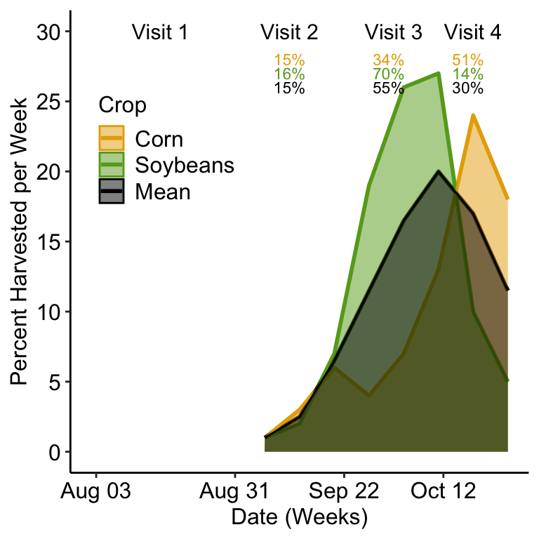

```r
# Wrangle Data
harvest <- read.csv("USDA_harvest_data.csv", header = TRUE) %>%
  mutate(Week.Ending = mdy(Week.Ending),
         Crop = ifelse(Commodity == "WHEAT" | Commodity == "OATS", "Summer", "Fall")) %>%
  filter(Week.Ending > "2020-08-01",
         Week.Ending < "2020-10-26") %>%
  dplyr::select(Week.Ending, Commodity, Value, Weekly.Value, Crop) %>%
  mutate(Commodity = fct_relevel(factor(Commodity), "OATS", "WHEAT", "BEANS", "CORN", "SORGHUM", "SOYBEANS"))
harvest_Lan <- harvest %>%
  ungroup() %>%
  filter(Commodity == "SOYBEANS" | Commodity == "CORN")
avg_Lan <- harvest_Lan %>%
  group_by(Week.Ending) %>%
  summarize(Weekly.Value = mean(Weekly.Value),
            Value = mean(Value)) %>%
  mutate(Commodity = "MEAN", Crop = "Mean")
combined_Lan <- rbind(harvest_Lan, avg_Lan)

# Make the Graph
ggplot() +
  geom_line(aes(x = Week.Ending, y = Weekly.Value,
                group = Commodity, color = Commodity),
            data = combined_Lan, linewidth = 1, alpha = 1) +
  geom_area(aes(x = Week.Ending, y = Weekly.Value,
                group = Commodity, color = Commodity, fill = Commodity),
            data = combined_Lan, alpha = 0.5, position = 'identity') +
  scale_color_manual("Crop", values = c("#e6ab02", "#66a61e", "black"),
                     labels = c("Corn", "Soybeans", "Mean")) +
  scale_fill_manual("Crop", values = c("#e6ab02", "#66a61e", "black"),
                     labels = c("Corn", "Soybeans", "Mean")) +
  scale_x_date(date_labels = "%b %d",
               limits = as.Date(c("2020-08-02", "2020-10-25")),
               breaks = as.Date(c("2020-08-03", "2020-08-31",
                                  "2020-09-22", "2020-10-12", ""))) +
  scale_y_continuous(limits = c(0, 30),
                     breaks = c(0, 5, 10, 15, 20, 25, 30)) +
  xlab("Date (Weeks)") +
  ylab("Percent Harvested per Week") +
  theme_classic() +
  theme(legend.key.size = unit(0.5, "cm"),
        text = element_text(size = 12),
        axis.title = element_text(size = 12, color = "black"),
        axis.text = element_text(size = 12, color = "black"),
        legend.text = element_text(size = 12, color = "black"),
        legend.title = element_text(size = 12, color = "black"),
        legend.position = c(0.21, 0.7)) +
  annotate(geom = "text", x = as.Date("2020-08-16"),
           y = 30, label = "Visit 1", color = "black", size = 4) +
  annotate(geom = "text", x = as.Date("2020-09-11"),
           y = 30, label = "Visit 2", color = "black", size = 4) +
  annotate(geom = "text", x = as.Date("2020-10-02"),
           y = 30, label = "Visit 3", color = "black", size = 4) +
  annotate(geom = "text", x = as.Date("2020-10-18"),
           y = 30, label = "Visit 4", color = "black", size = 4) +
  annotate(geom = "text", x = as.Date("2020-09-11"),
           y = 28, label = "15%", color = "#e6ab02", size = 3) +
  annotate(geom = "text", x = as.Date("2020-10-01"),
           y = 28, label = "34%", color = "#e6ab02", size = 3) +
  annotate(geom = "text", x = as.Date("2020-10-17"),
           y = 28, label = "51%", color = "#e6ab02", size = 3) +
  annotate(geom = "text", x = as.Date("2020-09-11"),
           y = 27, label = "16%", color = "#66a61e", size = 3) +
  annotate(geom = "text", x = as.Date("2020-10-01"),
           y = 27, label = "70%", color = "#66a61e", size = 3) +
  annotate(geom = "text", x = as.Date("2020-10-17"),
           y = 27, label = "14%", color = "#66a61e", size = 3) +
  annotate(geom = "text", x = as.Date("2020-09-11"),
           y = 26, label = "15%", color = "black", size = 3) +
  annotate(geom = "text", x = as.Date("2020-10-01"),
           y = 26, label = "55%", color = "black", size = 3) +
  annotate(geom = "text", x = as.Date("2020-10-17"),
           y = 26, label = "30%", color = "black", size = 3)
```

## Analyzing Energy Loss in Webs [R]

[**PUBLISHED IN CURRENT BIOLOGY**](https://doi.org/10.1016/j.cub.2025.02.041)

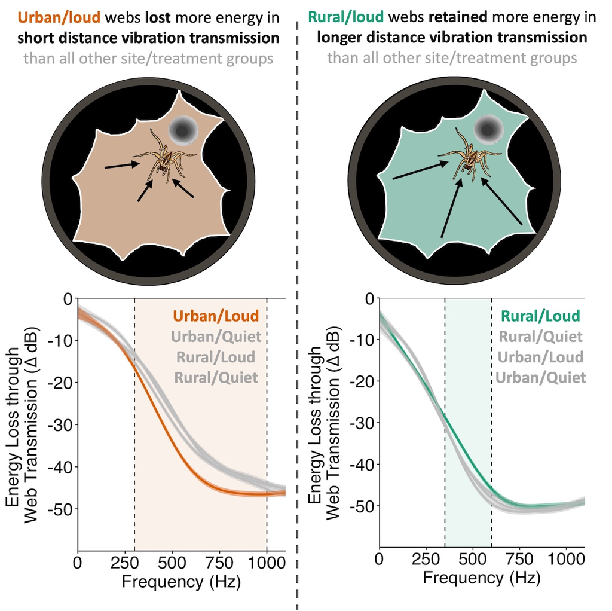

- **Tech Stack**: R, Raven Pro, Generalized Additive Models, Pairwise Comparisons
- **Motivation**: Explore the potential influence spiders have over the reception of information through their web when they experience noise.
- **Impact**: Uncovered how environmental noise influences vibratory properties of spider webs, revealing that spiders may adapt their web-building strategies to optimize signal transmission in noisy conditions.
- **GitHub**: https://github.com/brandipessman/Vibration_Transmission

– Employed a fully crossed design where spiders collected from rural (country) and urban (city) constructed webs under quiet (reflecting rural) or loud (reflecting urban) conditions.

– Engineered a novel method to measure energy loss as vibrations transmit across spider webs when vibrations were introduced at two distances.

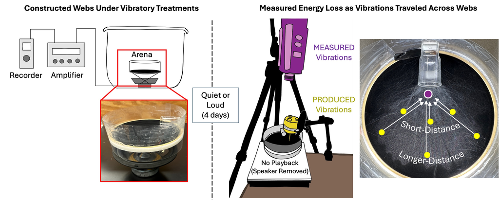

### GAM and Pairwise Comparisons

– Used generalized additive models (GAM) and pairwise comparisons of the estimated marginal means to compare energy loss in web vibrations within the range of noise (below 1000 Hz) and outside the range of noise (above 1000 Hz).

*Background lines are the calculated means across trials and spiders for each site/treatment group. The main lines and error ribbons represent the mean and 95% confidence interval of the predictions from the GAM. I used a GAM because the relationship was not linear.*

#### Short-Distance Transmission

**Webs constructed by urban (city) spiders under loud conditions lost significantly more energy in vibrations introduced near a foraging spider compared to all other site/treatment groups.** Urban spiders are likely bombarded by constant, high-amplitude noise, so this quieting of vibrations may act to reduce sensory overload and potentially hearing loss over the long term.

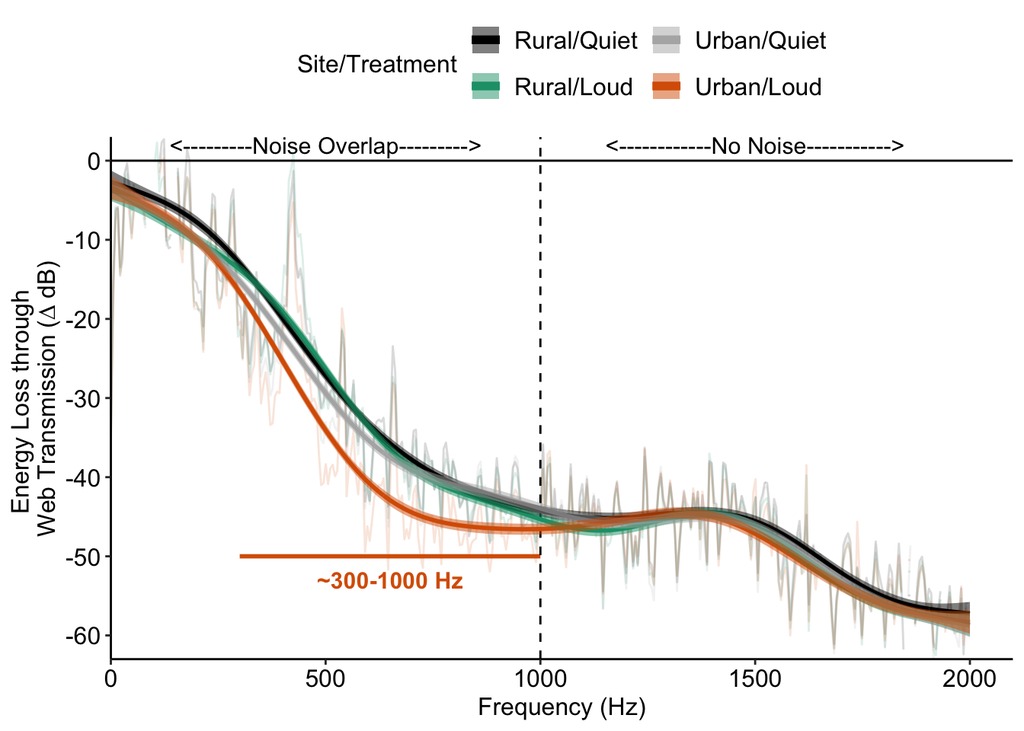

```r
# Wrangling Data
close_ind1 <- vibration_transmission2 %>%
  filter(Distance == "close") %>%
  mutate(treatment = factor(treatment),
         treatment = fct_relevel(treatment, "Quiet", "Loud"),
         Site = factor(Site),
         Site = fct_relevel(Site, "Rural", "Urban"),
         SpiderID = factor(SpiderID),
         Low_Freq = as.numeric(Low_Freq),
         Site_Treatment = factor(Site_Treatment),
         Site_Treatment= fct_recode(Site_Treatment,
                                    "Rural/Quiet" = "Rural_Quiet",
                                    "Rural/Loud" = "Rural_Loud",
                                    "Urban/Quiet" = "Urban_Quiet",
                                    "Urban/Loud" = "Urban_Loud"),
         Site_Treatment = fct_relevel(Site_Treatment,
                                      "Rural/Quiet", "Rural/Loud",
                                      "Urban/Quiet", "Urban/Loud"))

# Average Across Spiders For Each Site/Treatment
close_ind <- vibration_transmission2 %>%
  filter(Distance == "close") %>%
  group_by(Low_Freq, Site, treatment, Site_Treatment) %>%
  summarize(mean_snr = mean(spider_snr_db),
            se_snr = plotrix::std.error(spider_snr_db))%>%
  mutate(treatment = factor(treatment),
         treatment = fct_relevel(treatment, "Quiet", "Loud"),
         Site_Treatment = factor(Site_Treatment),
         Site_Treatment= fct_recode(Site_Treatment,
                                    "Rural/Quiet" = "Rural_Quiet",
                                    "Rural/Loud" = "Rural_Loud",
                                    "Urban/Quiet" = "Urban_Quiet",
                                    "Urban/Loud" = "Urban_Loud"),
         Site_Treatment = fct_relevel(Site_Treatment,
                                      "Rural/Quiet", "Rural/Loud",
                                      "Urban/Quiet", "Urban/Loud"))

# Generalized Additive Model
gam_model <- gam(spider_snr_db ~  Site_Treatment +
                   s(Low_Freq, by = Site_Treatment, k = 10),
                 data = close_ind1)

# Calculate Model Predictions
nd <- data.frame(expand.grid(Low_Freq = seq(0, 2000, 5),
                             Site = levels(factor(close_ind1$Site)),
                             treatment = levels(factor(close_ind1$treatment))))
nd <- nd %>%
  unite("Site_Treatment", Site, treatment, sep = "/", remove = FALSE)
predictions <- data.frame(predict(gam_model, newdata = nd, type = "response",
                       se.fit = TRUE))
predictions_short <- cbind(nd, predictions) %>%
  mutate(Site_Treatment = fct_relevel(factor(Site_Treatment),
                                      "Rural/Quiet", "Rural/Loud",
                                      "Urban/Quiet", "Urban/Loud"))

# Graph Model Predictions and Raw Data
ggplot() +
  annotate("segment", x = 300, xend = 1000, y = -50, color = "#D95F02",
           linetype = "solid", linewidth = 1) +
  annotate("text", x = 650, y = -53, color = "#D95F02",
           label = "~300-1000 Hz", fontface = "bold", size = 4) +
  annotate("text", x = 500, y = 2, color = "black",
           label = "<---------Noise Overlap--------->", size = 4) +
  annotate("text", x = 1500, y = 2, color = "black",
           label = "<------------No Noise----------->", size = 4) +
  geom_line(aes(x = Low_Freq, y = mean_snr, color = Site_Treatment),
            alpha = 0.15, data = close_ind) +
  geom_vline(aes(xintercept = 1000), linetype = "dashed") +
  geom_hline(aes(yintercept = 0), linetype = "solid") +
  geom_line(aes(x = Low_Freq, y = fit, color = Site_Treatment),
            linewidth = 1, data = predictions_short) +
  geom_ribbon(aes(x = Low_Freq, ymin = fit - (1.96 * se.fit),
                  ymax = fit + (1.96 * se.fit), fill = Site_Treatment),
              alpha = 0.5, data = predictions_short) +
  scale_y_continuous(limits = c(-63, 3),
                     breaks = c(seq(-60, 0, 10)), expand = c(0,0)) +
  scale_x_continuous(limits = c(0, 2100),
                     breaks = c(0, 500, 1000, 1500, 2000), expand = c(0,0)) +
  xlab("Frequency (Hz)") +
  ylab("Energy Loss through \nWeb Transmission (∆ dB)") +
  scale_fill_manual("Site/Treatment",
                    values = c("black", "#1b9e77", "grey70", "#d95f02")) +
  scale_color_manual("Site/Treatment",
                     values = c("black", "#1b9e77", "grey70", "#d95f02")) +
  theme_classic() +
  theme(axis.text = element_text(size = 12, color = "black"),
        axis.title = element_text(size = 12, color = "black"),
        legend.text = element_text(size = 12, color = "black"),
        legend.title = element_text(size = 12, color = "black"),
        strip.text = element_text(size = 12, color = "black"),
        plot.title = element_text(size = 12, color = "black"),
        legend.position = "top") +
  guides(color = guide_legend(nrow = 2, override.aes = list(linewidth = 2))) +
  guides(fill = guide_legend(nrow = 2))
```

```r
# Pairwise Comparison of Estimated Marginal Means
close_ind1_1000 <- close_ind1 %>%
  filter(Low_Freq < 1000)
gam_model_1000 <- gam(spider_snr_db ~  Site_Treatment +
                        s(Low_Freq, by = Site_Treatment, k = 10),
                      data = close_ind1_1000)
short_1000 <- data.frame(pairs(emmeans(gam_model_1000, ~Site_Treatment))) %>%
  dplyr::select(-df) %>%
  mutate(p.value = round(p.value, digits = 3),
         p.value = ifelse(p.value == 0, "< 0.001", p.value),
         p.value = ifelse(p.value < 0.001, paste0(p.value, "***"),
                   ifelse(p.value < 0.01, paste0(p.value, "**"),
                   ifelse(p.value < 0.05, paste0(p.value, "*"), p.value))))

close_ind1_2000 <- close_ind1 %>%
  filter(Low_Freq > 1000)
gam_model_2000 <- gam(spider_snr_db ~  Site_Treatment +
                        s(Low_Freq, by = Site_Treatment, k = 10),
                      data = close_ind1_2000)
short_2000 <- data.frame(pairs(emmeans(gam_model_2000, ~Site_Treatment))) %>%
  dplyr::select(-df) %>%
  mutate(p.value = round(p.value, digits = 3),
         p.value = ifelse(p.value == 0, "< 0.001", p.value),
         p.value = ifelse(p.value < 0.001, paste0(p.value, "***"),
                   ifelse(p.value < 0.01, paste0(p.value, "**"),
                   ifelse(p.value < 0.05, paste0(p.value, "*"), p.value))))

short <- full_join(short_1000, short_2000, by = "contrast")
colnames(short) <- c("Comparison", "Estimate", "Std.Err.", "t-value", "P-value", "Estimate ", "Std.Err. ", "t-value ", "P-value ")


kable(short, digits = 3, format = "html", caption = "Short-Distance Transmission Pairwise Comparisons") %>%
  kable_classic() %>%
  add_header_above(c(" " = 1, "Below 1000 Hz" = 4, "Above 1000 Hz" = 4)) %>%
  column_spec(5, border_right = "1px solid black") %>%
  column_spec(1, border_right = "1px solid black") %>%
  row_spec(c(3, 5:6), background = "#fed6b7") %>%
  column_spec(c(6:9), background = "transparent") %>%
  kable_styling(full_width = FALSE, position = "center")
```

Short-Distance Transmission Pairwise Comparisons

| Comparison | Below 1000 Hz Estimate | Below 1000 Hz Std.Err. | Below 1000 Hz t-value | Below 1000 Hz P-value | Above 1000 Hz Estimate | Above 1000 Hz Std.Err. | Above 1000 Hz t-value | Above 1000 Hz P-value |
| --- | --- | --- | --- | --- | --- | --- | --- | --- |
| (Rural/Quiet) - (Rural/Loud) | -1.277 | 0.781 | -1.635 | 0.359 | 0.942 | 0.543 | 1.736 | 0.305 |
| (Rural/Quiet) - (Urban/Quiet) | 2.334 | 0.782 | 2.983 | 0.015* | 0.880 | 0.534 | 1.647 | 0.352 |
| (Rural/Quiet) - (Urban/Loud) | 6.941 | 0.786 | 8.835 | < 0.001*** | 1.779 | 0.539 | 3.301 | 0.005** |
| (Rural/Loud) - (Urban/Quiet) | 3.610 | 0.781 | 4.624 | < 0.001*** | -0.063 | 0.543 | -0.115 | 0.999 |
| (Rural/Loud) - (Urban/Loud) | 8.218 | 0.784 | 10.479 | < 0.001*** | 0.837 | 0.548 | 1.526 | 0.422 |
| (Urban/Quiet) - (Urban/Loud) | 4.608 | 0.786 | 5.863 | < 0.001*** | 0.899 | 0.540 | 1.667 | 0.341 |

#### Longer-Distance Transmission

**Webs constructed by rural (country) spiders under loud conditions retained significantly more energy in vibrations introduced further from a foraging spider compared to all other site/treatment groups.** During temporary increases in noise during harvesting activities, rural spiders may retain more energy from longer-distance vibrations to improve the reception of relevant information from prey and mates.

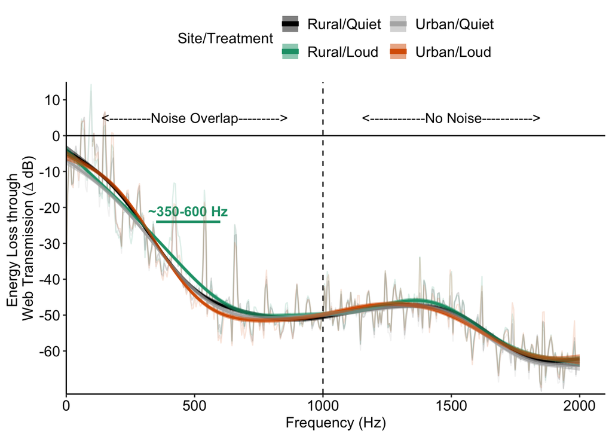

```r
# Wrangling Data
far_ind1 <- vibration_transmission2 %>%
  filter(Distance == "far") %>%
  mutate(treatment = factor(treatment),
         treatment = fct_relevel(treatment, "Quiet", "Loud"),
         Site = factor(Site),
         Site = fct_relevel(Site, "Rural", "Urban"),
         Low_Freq = as.numeric(Low_Freq),
         Site_Treatment = factor(Site_Treatment),
         Site_Treatment= fct_recode(Site_Treatment,
                                    "Rural/Quiet" = "Rural_Quiet",
                                    "Rural/Loud" = "Rural_Loud",
                                    "Urban/Quiet" = "Urban_Quiet",
                                    "Urban/Loud" = "Urban_Loud"),
         Site_Treatment = fct_relevel(Site_Treatment,
                                      "Rural/Quiet", "Rural/Loud",
                                      "Urban/Quiet", "Urban/Loud"))

# Average Across Spiders For Each Site/Treatment
far_ind <- vibration_transmission2 %>%
  filter(Distance == "far") %>%
  group_by(Low_Freq, Site, treatment, Site_Treatment) %>%
  summarize(mean_snr = mean(spider_snr_db),
            se_snr = plotrix::std.error(spider_snr_db))%>%
  mutate(treatment = factor(treatment),
         treatment = fct_relevel(treatment, "Quiet", "Loud"),
         Site = factor(Site),
         Site = fct_relevel(Site, "Rural", "Urban"),
         Site_Treatment = factor(Site_Treatment),
         Site_Treatment= fct_recode(Site_Treatment,
                                    "Rural/Quiet" = "Rural_Quiet",
                                    "Rural/Loud" = "Rural_Loud",
                                    "Urban/Quiet" = "Urban_Quiet",
                                    "Urban/Loud" = "Urban_Loud"),
         Site_Treatment = fct_relevel(Site_Treatment,
                                      "Rural/Quiet", "Rural/Loud",
                                      "Urban/Quiet", "Urban/Loud"))

# Generalized Additive Model
gam_model <- gam(spider_snr_db ~ Site_Treatment + s(Low_Freq, by = Site_Treatment, k = 10), data = far_ind1)

# Calculate Model Predictions
nd <- data.frame(expand.grid(Low_Freq = seq(0, 2000, 5),
                             Site = levels(factor(far_ind1$Site)),
                             treatment = levels(factor(far_ind1$treatment))))
nd <- nd %>%
  unite("Site_Treatment", Site, treatment, sep = "/", remove = FALSE)
predictions <- data.frame(predict(gam_model, newdata = nd, type = "response",
                       se.fit = TRUE))
predictions_long <- cbind(nd, predictions) %>%
  mutate(Site_Treatment = fct_relevel(factor(Site_Treatment),
                                      "Rural/Quiet", "Rural/Loud",
                                      "Urban/Quiet", "Urban/Loud"))

# Graph Model Predictions and Raw Data
ggplot() +
  annotate("segment", x = 350, xend = 600, y = -24, color = "#1b9e77",
           linetype = "solid", linewidth = 1) +
  annotate("text", x = 475, y = -21, color = "#1b9e77",
           label = "~350-600 Hz", fontface = "bold", size = 4) +
  annotate("text", x = 500, y = 5, color = "black",
           label = "<---------Noise Overlap--------->", size = 4) +
  annotate("text", x = 1500, y = 5, color = "black",
           label = "<------------No Noise----------->", size = 4) +
  geom_line(aes(x = Low_Freq, y = mean_snr, color = Site_Treatment),
            alpha = 0.15, data = far_ind) +
  geom_vline(aes(xintercept = 1000), linetype = "dashed") +
  geom_hline(aes(yintercept = 0), linetype = "solid") +
  geom_line(aes(x = Low_Freq, y = fit, color = Site_Treatment),
            linewidth = 1, data = predictions_long) +
  geom_ribbon(aes(x = Low_Freq, ymin = fit - 1.96 * se.fit,
                  ymax = fit + 1.96 * se.fit, fill = Site_Treatment),
              alpha = 0.5, data = predictions_long) +
  scale_y_continuous(limits = c(-72, 15),
                     breaks = c(seq(-60, 10, 10)), expand = c(0,0)) +
  scale_x_continuous(limits = c(0, 2100),
                     breaks = c(0, 500, 1000, 1500, 2000), expand = c(0,0)) +
  xlab("Frequency (Hz)") +
  ylab("Energy Loss through \nWeb Transmission (∆ dB)") +
  scale_fill_manual("Site/Treatment",
                    values = c("black", "#1b9e77", "grey70", "#d95f02")) +
  scale_color_manual("Site/Treatment",
                     values = c("black", "#1b9e77", "grey70", "#d95f02")) +
  scale_linetype_manual("Site_Treatment",
                        values = c("dashed", "solid", "dashed", "solid")) +
  theme_classic() +
  theme(axis.text = element_text(size = 12, color = "black"),
        axis.title = element_text(size = 12, color = "black"),
        legend.text = element_text(size = 12, color = "black"),
        legend.title = element_text(size = 12, color = "black"),
        strip.text = element_text(size = 12, color = "black"),
        plot.title = element_text(size = 12, color = "black"),
        legend.position = "top") +
  guides(color = guide_legend(nrow = 2, override.aes = list(linewidth = 2))) +
  guides(fill = guide_legend(nrow = 2))
```

```r
# Pairwise Comparison of Estimated Marginal Means
far_ind1_1000 <- far_ind1 %>%
  filter(Low_Freq < 1000)
gam_model_1000 <- gam(spider_snr_db ~  Site_Treatment + s(Low_Freq, by = Site_Treatment, k = 10), data = far_ind1_1000)
long_1000 <- data.frame(pairs(emmeans(gam_model_1000, ~Site_Treatment))) %>%
  dplyr::select(-df) %>%
  mutate(p.value = round(p.value, digits = 3),
         p.value = ifelse(p.value == 0, "< 0.001", p.value),
         p.value = ifelse(p.value < 0.001, paste0(p.value, "***"),
                   ifelse(p.value < 0.01, paste0(p.value, "**"),
                   ifelse(p.value < 0.05, paste0(p.value, "*"), p.value))))

far_ind1_2000 <- far_ind1 %>%
  filter(Low_Freq > 1000)
gam_model_2000 <- gam(spider_snr_db ~  Site_Treatment + s(Low_Freq, by = Site_Treatment, k = 10), data = far_ind1_2000)
long_2000 <- data.frame(pairs(emmeans(gam_model_2000, ~Site_Treatment))) %>%
  dplyr::select(-df) %>%
  mutate(p.value = round(p.value, digits = 3),
         p.value = ifelse(p.value == 0, "< 0.001", p.value),
         p.value = ifelse(p.value < 0.001, paste0(p.value, "***"),
                   ifelse(p.value < 0.01, paste0(p.value, "**"),
                   ifelse(p.value < 0.05, paste0(p.value, "*"), p.value))))

long <- full_join(long_1000, long_2000, by = "contrast")
colnames(short) <- c("Comparison", "Estimate", "Std.Err.", "t-value", "P-value", "Estimate ", "Std.Err. ", "t-value ", "P-value ")


kable(long, digits = 3, format = "html", caption = "Longer-Distance Transmission Pairwise Comparisons") %>%
  kable_classic() %>%
  add_header_above(c(" " = 1, "Below 1000 Hz" = 4, "Above 1000 Hz" = 4)) %>%
  column_spec(5, border_right = "1px solid black") %>%
  column_spec(1, border_right = "1px solid black") %>%
  row_spec(c(1, 4:5), background = "#baf3e2") %>%
  column_spec(c(6:9), background = "transparent") %>%
  kable_styling(full_width = FALSE, position = "center")
```

Longer-Distance Transmission Pairwise Comparisons

| contrast | Below 1000 Hz estimate.x | Below 1000 Hz SE.x | Below 1000 Hz t.ratio.x | Below 1000 Hz p.value.x | Above 1000 Hz estimate.y | Above 1000 Hz SE.y | Above 1000 Hz t.ratio.y | Above 1000 Hz p.value.y |
| --- | --- | --- | --- | --- | --- | --- | --- | --- |
| (Rural/Quiet) - (Rural/Loud) | -3.103 | 0.744 | -4.167 | < 0.001*** | -0.195 | 0.521 | -0.374 | 0.982 |
| (Rural/Quiet) - (Urban/Quiet) | 0.430 | 0.744 | 0.577 | 0.939 | 0.890 | 0.520 | 1.711 | 0.318 |
| (Rural/Quiet) - (Urban/Loud) | 1.291 | 0.744 | 1.735 | 0.306 | 1.544 | 0.524 | 2.948 | 0.017* |
| (Rural/Loud) - (Urban/Quiet) | 3.532 | 0.745 | 4.743 | < 0.001*** | 1.085 | 0.516 | 2.103 | 0.152 |
| (Rural/Loud) - (Urban/Loud) | 4.394 | 0.745 | 5.901 | < 0.001*** | 1.738 | 0.519 | 3.347 | 0.005** |
| (Urban/Quiet) - (Urban/Loud) | 0.862 | 0.744 | 1.157 | 0.654 | 0.654 | 0.519 | 1.261 | 0.588 |